```python
#وارد کردن کتابخانه های ی مورد نیاز
import pandas as pd
import matplotlib.pyplot as plt
import numpy as np
```

```python
#تعریف دیتا فریم مربوط به گرگان
df=pd.read_csv('gorgan_census95_activity.csv')
df
```

|  | county_name | settlement | gender | age_group | p_active_emp | p_active_unemp | p_inactive_edu | p_inactive_homemaker | p_inactive_incomeNojob | p_inactive_other | p_not_stated | p_total | emp_ratio |
| --- | --- | --- | --- | --- | --- | --- | --- | --- | --- | --- | --- | --- | --- |
| 0 | گرگان | شهري | مرد | 10-14 | 57 | 7 | 12361 | 16 | 1 | 261 | 2 | 12705 | 0.004486 |
| 1 | گرگان | شهري | مرد | 15-19 | 1148 | 292 | 9747 | 33 | 8 | 905 | 6 | 12139 | 0.094571 |
| 2 | گرگان | شهري | مرد | 20-24 | 3526 | 1996 | 5693 | 49 | 27 | 2032 | 11 | 13334 | 0.264437 |
| 3 | گرگان | شهري | مرد | 25-29 | 11176 | 3554 | 2025 | 59 | 54 | 1037 | 10 | 17915 | 0.623835 |
| 4 | گرگان | شهري | مرد | 30-34 | 15532 | 2543 | 898 | 70 | 97 | 1470 | 13 | 20623 | 0.753140 |
| 5 | گرگان | شهري | مرد | 35-39 | 14729 | 1292 | 516 | 48 | 115 | 417 | 11 | 17128 | 0.859937 |
| 6 | گرگان | شهري | مرد | 40-44 | 12561 | 669 | 293 | 39 | 206 | 187 | 7 | 13962 | 0.899656 |
| 7 | گرگان | شهري | مرد | 45-49 | 11019 | 265 | 218 | 36 | 869 | 106 | 10 | 12523 | 0.879901 |
| 8 | گرگان | شهري | مرد | 50-54 | 7482 | 151 | 77 | 29 | 2651 | 52 | 5 | 10447 | 0.716186 |
| 9 | گرگان | شهري | مرد | 55-59 | 5030 | 67 | 51 | 29 | 3193 | 21 | 6 | 8397 | 0.599023 |
| 10 | گرگان | شهري | مرد | 60-64 | 2271 | 27 | 14 | 34 | 3473 | 2 | 1 | 5822 | 0.390072 |
| 11 | گرگان | شهري | مرد | 65+ | 1238 | 25 | 2 | 82 | 5996 | 1950 | 9 | 9302 | 0.133090 |
| 12 | گرگان | شهري | زن | 10-14 | 33 | 4 | 11813 | 140 | 1 | 129 | 0 | 12120 | 0.002723 |
| 13 | گرگان | شهري | زن | 15-19 | 253 | 135 | 9546 | 1637 | 4 | 634 | 3 | 12212 | 0.020717 |
| 14 | گرگان | شهري | زن | 20-24 | 710 | 1070 | 6796 | 5200 | 7 | 942 | 1 | 14726 | 0.048214 |
| 15 | گرگان | شهري | زن | 25-29 | 3136 | 2116 | 2488 | 10950 | 41 | 486 | 2 | 19219 | 0.163172 |
| 16 | گرگان | شهري | زن | 30-34 | 4146 | 1450 | 1390 | 13699 | 85 | 1052 | 6 | 21828 | 0.189940 |
| 17 | گرگان | شهري | زن | 35-39 | 4079 | 705 | 664 | 11496 | 116 | 389 | 0 | 17449 | 0.233767 |
| 18 | گرگان | شهري | زن | 40-44 | 2900 | 249 | 280 | 9402 | 167 | 757 | 4 | 13759 | 0.210771 |
| 19 | گرگان | شهري | زن | 45-49 | 2326 | 113 | 140 | 8490 | 356 | 385 | 3 | 11813 | 0.196902 |
| 20 | گرگان | شهري | زن | 50-54 | 1379 | 58 | 45 | 7727 | 759 | 82 | 2 | 10052 | 0.137187 |
| 21 | گرگان | شهري | زن | 55-59 | 664 | 14 | 16 | 6043 | 1347 | 31 | 2 | 8117 | 0.081804 |
| 22 | گرگان | شهري | زن | 60-64 | 333 | 3 | 3 | 4262 | 1310 | 11 | 2 | 5924 | 0.056212 |
| 23 | گرگان | شهري | زن | 65+ | 343 | 1 | 0 | 6516 | 2208 | 511 | 8 | 9587 | 0.035778 |
| 24 | گرگان | روستايي | مرد | 10-14 | 45 | 4 | 4009 | 17 | 1 | 214 | 1 | 4291 | 0.010487 |
| 25 | گرگان | روستايي | مرد | 15-19 | 930 | 126 | 2209 | 23 | 5 | 519 | 41 | 3853 | 0.241370 |
| 26 | گرگان | روستايي | مرد | 20-24 | 2036 | 941 | 791 | 17 | 17 | 851 | 278 | 4931 | 0.412898 |
| 27 | گرگان | روستايي | مرد | 25-29 | 4141 | 1160 | 267 | 20 | 12 | 388 | 495 | 6483 | 0.638747 |
| 28 | گرگان | روستايي | مرد | 30-34 | 5007 | 659 | 94 | 19 | 24 | 138 | 591 | 6532 | 0.766534 |
| 29 | گرگان | روستايي | مرد | 35-39 | 4361 | 176 | 44 | 11 | 31 | 33 | 497 | 5153 | 0.846303 |
| 30 | گرگان | روستايي | مرد | 40-44 | 3891 | 75 | 39 | 10 | 47 | 43 | 299 | 4404 | 0.883515 |
| 31 | گرگان | روستايي | مرد | 45-49 | 3106 | 32 | 17 | 12 | 123 | 15 | 182 | 3487 | 0.890737 |
| 32 | گرگان | روستايي | مرد | 50-54 | 2336 | 23 | 7 | 13 | 295 | 3 | 102 | 2779 | 0.840590 |
| 33 | گرگان | روستايي | مرد | 55-59 | 1926 | 15 | 2 | 11 | 393 | 2 | 66 | 2415 | 0.797516 |
| 34 | گرگان | روستايي | مرد | 60-64 | 1271 | 11 | 0 | 12 | 398 | 0 | 27 | 1719 | 0.739383 |
| 35 | گرگان | روستايي | مرد | 65+ | 1074 | 11 | 1 | 52 | 877 | 1418 | 21 | 3454 | 0.310944 |
| 36 | گرگان | روستايي | زن | 10-14 | 16 | 5 | 3857 | 183 | 0 | 137 | 2 | 4200 | 0.003810 |
| 37 | گرگان | روستايي | زن | 15-19 | 156 | 65 | 1839 | 1215 | 3 | 223 | 3 | 3504 | 0.044521 |
| 38 | گرگان | روستايي | زن | 20-24 | 210 | 227 | 723 | 2700 | 4 | 260 | 15 | 4139 | 0.050737 |
| 39 | گرگان | روستايي | زن | 25-29 | 604 | 304 | 226 | 4254 | 6 | 96 | 12 | 5502 | 0.109778 |
| 40 | گرگان | روستايي | زن | 30-34 | 652 | 188 | 105 | 4620 | 8 | 90 | 15 | 5678 | 0.114829 |
| 41 | گرگان | روستايي | زن | 35-39 | 568 | 91 | 47 | 3851 | 11 | 71 | 26 | 4665 | 0.121758 |
| 42 | گرگان | روستايي | زن | 40-44 | 454 | 42 | 22 | 3365 | 16 | 70 | 10 | 3979 | 0.114099 |
| 43 | گرگان | روستايي | زن | 45-49 | 384 | 20 | 5 | 2747 | 29 | 29 | 9 | 3223 | 0.119144 |
| 44 | گرگان | روستايي | زن | 50-54 | 308 | 10 | 1 | 2572 | 59 | 16 | 5 | 2971 | 0.103669 |
| 45 | گرگان | روستايي | زن | 55-59 | 280 | 1 | 1 | 2040 | 91 | 5 | 6 | 2424 | 0.115512 |
| 46 | گرگان | روستايي | زن | 60-64 | 202 | 1 | 1 | 1672 | 102 | 2 | 3 | 1983 | 0.101866 |
| 47 | گرگان | روستايي | زن | 65+ | 216 | 0 | 3 | 2815 | 337 | 460 | 4 | 3835 | 0.056323 |

```python
#جدا کردن گروه های سنی 14 تا 65 سال
df_age_15_64=df[df['age_group']!='10-14'][df[df['age_group']!='10-14']['age_group']!='65+']
df_age_15_64
```

|  | county_name | settlement | gender | age_group | p_active_emp | p_active_unemp | p_inactive_edu | p_inactive_homemaker | p_inactive_incomeNojob | p_inactive_other | p_not_stated | p_total | emp_ratio |
| --- | --- | --- | --- | --- | --- | --- | --- | --- | --- | --- | --- | --- | --- |
| 1 | گرگان | شهري | مرد | 15-19 | 1148 | 292 | 9747 | 33 | 8 | 905 | 6 | 12139 | 0.094571 |
| 2 | گرگان | شهري | مرد | 20-24 | 3526 | 1996 | 5693 | 49 | 27 | 2032 | 11 | 13334 | 0.264437 |
| 3 | گرگان | شهري | مرد | 25-29 | 11176 | 3554 | 2025 | 59 | 54 | 1037 | 10 | 17915 | 0.623835 |
| 4 | گرگان | شهري | مرد | 30-34 | 15532 | 2543 | 898 | 70 | 97 | 1470 | 13 | 20623 | 0.753140 |
| 5 | گرگان | شهري | مرد | 35-39 | 14729 | 1292 | 516 | 48 | 115 | 417 | 11 | 17128 | 0.859937 |
| 6 | گرگان | شهري | مرد | 40-44 | 12561 | 669 | 293 | 39 | 206 | 187 | 7 | 13962 | 0.899656 |
| 7 | گرگان | شهري | مرد | 45-49 | 11019 | 265 | 218 | 36 | 869 | 106 | 10 | 12523 | 0.879901 |
| 8 | گرگان | شهري | مرد | 50-54 | 7482 | 151 | 77 | 29 | 2651 | 52 | 5 | 10447 | 0.716186 |
| 9 | گرگان | شهري | مرد | 55-59 | 5030 | 67 | 51 | 29 | 3193 | 21 | 6 | 8397 | 0.599023 |
| 10 | گرگان | شهري | مرد | 60-64 | 2271 | 27 | 14 | 34 | 3473 | 2 | 1 | 5822 | 0.390072 |
| 13 | گرگان | شهري | زن | 15-19 | 253 | 135 | 9546 | 1637 | 4 | 634 | 3 | 12212 | 0.020717 |
| 14 | گرگان | شهري | زن | 20-24 | 710 | 1070 | 6796 | 5200 | 7 | 942 | 1 | 14726 | 0.048214 |
| 15 | گرگان | شهري | زن | 25-29 | 3136 | 2116 | 2488 | 10950 | 41 | 486 | 2 | 19219 | 0.163172 |
| 16 | گرگان | شهري | زن | 30-34 | 4146 | 1450 | 1390 | 13699 | 85 | 1052 | 6 | 21828 | 0.189940 |
| 17 | گرگان | شهري | زن | 35-39 | 4079 | 705 | 664 | 11496 | 116 | 389 | 0 | 17449 | 0.233767 |
| 18 | گرگان | شهري | زن | 40-44 | 2900 | 249 | 280 | 9402 | 167 | 757 | 4 | 13759 | 0.210771 |
| 19 | گرگان | شهري | زن | 45-49 | 2326 | 113 | 140 | 8490 | 356 | 385 | 3 | 11813 | 0.196902 |
| 20 | گرگان | شهري | زن | 50-54 | 1379 | 58 | 45 | 7727 | 759 | 82 | 2 | 10052 | 0.137187 |
| 21 | گرگان | شهري | زن | 55-59 | 664 | 14 | 16 | 6043 | 1347 | 31 | 2 | 8117 | 0.081804 |
| 22 | گرگان | شهري | زن | 60-64 | 333 | 3 | 3 | 4262 | 1310 | 11 | 2 | 5924 | 0.056212 |
| 25 | گرگان | روستايي | مرد | 15-19 | 930 | 126 | 2209 | 23 | 5 | 519 | 41 | 3853 | 0.241370 |
| 26 | گرگان | روستايي | مرد | 20-24 | 2036 | 941 | 791 | 17 | 17 | 851 | 278 | 4931 | 0.412898 |
| 27 | گرگان | روستايي | مرد | 25-29 | 4141 | 1160 | 267 | 20 | 12 | 388 | 495 | 6483 | 0.638747 |
| 28 | گرگان | روستايي | مرد | 30-34 | 5007 | 659 | 94 | 19 | 24 | 138 | 591 | 6532 | 0.766534 |
| 29 | گرگان | روستايي | مرد | 35-39 | 4361 | 176 | 44 | 11 | 31 | 33 | 497 | 5153 | 0.846303 |
| 30 | گرگان | روستايي | مرد | 40-44 | 3891 | 75 | 39 | 10 | 47 | 43 | 299 | 4404 | 0.883515 |
| 31 | گرگان | روستايي | مرد | 45-49 | 3106 | 32 | 17 | 12 | 123 | 15 | 182 | 3487 | 0.890737 |
| 32 | گرگان | روستايي | مرد | 50-54 | 2336 | 23 | 7 | 13 | 295 | 3 | 102 | 2779 | 0.840590 |
| 33 | گرگان | روستايي | مرد | 55-59 | 1926 | 15 | 2 | 11 | 393 | 2 | 66 | 2415 | 0.797516 |
| 34 | گرگان | روستايي | مرد | 60-64 | 1271 | 11 | 0 | 12 | 398 | 0 | 27 | 1719 | 0.739383 |
| 37 | گرگان | روستايي | زن | 15-19 | 156 | 65 | 1839 | 1215 | 3 | 223 | 3 | 3504 | 0.044521 |
| 38 | گرگان | روستايي | زن | 20-24 | 210 | 227 | 723 | 2700 | 4 | 260 | 15 | 4139 | 0.050737 |
| 39 | گرگان | روستايي | زن | 25-29 | 604 | 304 | 226 | 4254 | 6 | 96 | 12 | 5502 | 0.109778 |
| 40 | گرگان | روستايي | زن | 30-34 | 652 | 188 | 105 | 4620 | 8 | 90 | 15 | 5678 | 0.114829 |
| 41 | گرگان | روستايي | زن | 35-39 | 568 | 91 | 47 | 3851 | 11 | 71 | 26 | 4665 | 0.121758 |
| 42 | گرگان | روستايي | زن | 40-44 | 454 | 42 | 22 | 3365 | 16 | 70 | 10 | 3979 | 0.114099 |
| 43 | گرگان | روستايي | زن | 45-49 | 384 | 20 | 5 | 2747 | 29 | 29 | 9 | 3223 | 0.119144 |
| 44 | گرگان | روستايي | زن | 50-54 | 308 | 10 | 1 | 2572 | 59 | 16 | 5 | 2971 | 0.103669 |
| 45 | گرگان | روستايي | زن | 55-59 | 280 | 1 | 1 | 2040 | 91 | 5 | 6 | 2424 | 0.115512 |
| 46 | گرگان | روستايي | زن | 60-64 | 202 | 1 | 1 | 1672 | 102 | 2 | 3 | 1983 | 0.101866 |

## 1.1

```python
#تقسیم مجموع مقادیر شاغل به مقدار کل
print(round(df_age_15_64.p_active_emp.sum()/df_age_15_64.p_total.sum()*100,3),"%")
```

```
39.521 %
```

```python
#تفکیک جمعیت شهری
df_age_15_64_urban=df_age_15_64[df_age_15_64['settlement']=='شهري']
df_age_15_64_urban
```

|  | county_name | settlement | gender | age_group | p_active_emp | p_active_unemp | p_inactive_edu | p_inactive_homemaker | p_inactive_incomeNojob | p_inactive_other | p_not_stated | p_total | emp_ratio |
| --- | --- | --- | --- | --- | --- | --- | --- | --- | --- | --- | --- | --- | --- |
| 1 | گرگان | شهري | مرد | 15-19 | 1148 | 292 | 9747 | 33 | 8 | 905 | 6 | 12139 | 0.094571 |
| 2 | گرگان | شهري | مرد | 20-24 | 3526 | 1996 | 5693 | 49 | 27 | 2032 | 11 | 13334 | 0.264437 |
| 3 | گرگان | شهري | مرد | 25-29 | 11176 | 3554 | 2025 | 59 | 54 | 1037 | 10 | 17915 | 0.623835 |
| 4 | گرگان | شهري | مرد | 30-34 | 15532 | 2543 | 898 | 70 | 97 | 1470 | 13 | 20623 | 0.753140 |
| 5 | گرگان | شهري | مرد | 35-39 | 14729 | 1292 | 516 | 48 | 115 | 417 | 11 | 17128 | 0.859937 |
| 6 | گرگان | شهري | مرد | 40-44 | 12561 | 669 | 293 | 39 | 206 | 187 | 7 | 13962 | 0.899656 |
| 7 | گرگان | شهري | مرد | 45-49 | 11019 | 265 | 218 | 36 | 869 | 106 | 10 | 12523 | 0.879901 |
| 8 | گرگان | شهري | مرد | 50-54 | 7482 | 151 | 77 | 29 | 2651 | 52 | 5 | 10447 | 0.716186 |
| 9 | گرگان | شهري | مرد | 55-59 | 5030 | 67 | 51 | 29 | 3193 | 21 | 6 | 8397 | 0.599023 |
| 10 | گرگان | شهري | مرد | 60-64 | 2271 | 27 | 14 | 34 | 3473 | 2 | 1 | 5822 | 0.390072 |
| 13 | گرگان | شهري | زن | 15-19 | 253 | 135 | 9546 | 1637 | 4 | 634 | 3 | 12212 | 0.020717 |
| 14 | گرگان | شهري | زن | 20-24 | 710 | 1070 | 6796 | 5200 | 7 | 942 | 1 | 14726 | 0.048214 |
| 15 | گرگان | شهري | زن | 25-29 | 3136 | 2116 | 2488 | 10950 | 41 | 486 | 2 | 19219 | 0.163172 |
| 16 | گرگان | شهري | زن | 30-34 | 4146 | 1450 | 1390 | 13699 | 85 | 1052 | 6 | 21828 | 0.189940 |
| 17 | گرگان | شهري | زن | 35-39 | 4079 | 705 | 664 | 11496 | 116 | 389 | 0 | 17449 | 0.233767 |
| 18 | گرگان | شهري | زن | 40-44 | 2900 | 249 | 280 | 9402 | 167 | 757 | 4 | 13759 | 0.210771 |
| 19 | گرگان | شهري | زن | 45-49 | 2326 | 113 | 140 | 8490 | 356 | 385 | 3 | 11813 | 0.196902 |
| 20 | گرگان | شهري | زن | 50-54 | 1379 | 58 | 45 | 7727 | 759 | 82 | 2 | 10052 | 0.137187 |
| 21 | گرگان | شهري | زن | 55-59 | 664 | 14 | 16 | 6043 | 1347 | 31 | 2 | 8117 | 0.081804 |
| 22 | گرگان | شهري | زن | 60-64 | 333 | 3 | 3 | 4262 | 1310 | 11 | 2 | 5924 | 0.056212 |

```python
#تفکیک جمعیت روستایی
df_age_15_64_rural=df_age_15_64[df_age_15_64['settlement']=='روستايي']
df_age_15_64_rural
```

|  | county_name | settlement | gender | age_group | p_active_emp | p_active_unemp | p_inactive_edu | p_inactive_homemaker | p_inactive_incomeNojob | p_inactive_other | p_not_stated | p_total | emp_ratio |
| --- | --- | --- | --- | --- | --- | --- | --- | --- | --- | --- | --- | --- | --- |
| 25 | گرگان | روستايي | مرد | 15-19 | 930 | 126 | 2209 | 23 | 5 | 519 | 41 | 3853 | 0.241370 |
| 26 | گرگان | روستايي | مرد | 20-24 | 2036 | 941 | 791 | 17 | 17 | 851 | 278 | 4931 | 0.412898 |
| 27 | گرگان | روستايي | مرد | 25-29 | 4141 | 1160 | 267 | 20 | 12 | 388 | 495 | 6483 | 0.638747 |
| 28 | گرگان | روستايي | مرد | 30-34 | 5007 | 659 | 94 | 19 | 24 | 138 | 591 | 6532 | 0.766534 |
| 29 | گرگان | روستايي | مرد | 35-39 | 4361 | 176 | 44 | 11 | 31 | 33 | 497 | 5153 | 0.846303 |
| 30 | گرگان | روستايي | مرد | 40-44 | 3891 | 75 | 39 | 10 | 47 | 43 | 299 | 4404 | 0.883515 |
| 31 | گرگان | روستايي | مرد | 45-49 | 3106 | 32 | 17 | 12 | 123 | 15 | 182 | 3487 | 0.890737 |
| 32 | گرگان | روستايي | مرد | 50-54 | 2336 | 23 | 7 | 13 | 295 | 3 | 102 | 2779 | 0.840590 |
| 33 | گرگان | روستايي | مرد | 55-59 | 1926 | 15 | 2 | 11 | 393 | 2 | 66 | 2415 | 0.797516 |
| 34 | گرگان | روستايي | مرد | 60-64 | 1271 | 11 | 0 | 12 | 398 | 0 | 27 | 1719 | 0.739383 |
| 37 | گرگان | روستايي | زن | 15-19 | 156 | 65 | 1839 | 1215 | 3 | 223 | 3 | 3504 | 0.044521 |
| 38 | گرگان | روستايي | زن | 20-24 | 210 | 227 | 723 | 2700 | 4 | 260 | 15 | 4139 | 0.050737 |
| 39 | گرگان | روستايي | زن | 25-29 | 604 | 304 | 226 | 4254 | 6 | 96 | 12 | 5502 | 0.109778 |
| 40 | گرگان | روستايي | زن | 30-34 | 652 | 188 | 105 | 4620 | 8 | 90 | 15 | 5678 | 0.114829 |
| 41 | گرگان | روستايي | زن | 35-39 | 568 | 91 | 47 | 3851 | 11 | 71 | 26 | 4665 | 0.121758 |
| 42 | گرگان | روستايي | زن | 40-44 | 454 | 42 | 22 | 3365 | 16 | 70 | 10 | 3979 | 0.114099 |
| 43 | گرگان | روستايي | زن | 45-49 | 384 | 20 | 5 | 2747 | 29 | 29 | 9 | 3223 | 0.119144 |
| 44 | گرگان | روستايي | زن | 50-54 | 308 | 10 | 1 | 2572 | 59 | 16 | 5 | 2971 | 0.103669 |
| 45 | گرگان | روستايي | زن | 55-59 | 280 | 1 | 1 | 2040 | 91 | 5 | 6 | 2424 | 0.115512 |
| 46 | گرگان | روستايي | زن | 60-64 | 202 | 1 | 1 | 1672 | 102 | 2 | 3 | 1983 | 0.101866 |

## 1.2

```python
#تقسیم جمعیت شاغل شهری به کل جمعیت شهری
urban_ratio_gorgan=round(df_age_15_64_urban.p_active_emp.sum()/df_age_15_64_urban.p_total.sum()*100,3)
print(urban_ratio_gorgan,"%")
```

```
39.044 %
```

```python
#تقسیم جمعیت شاغل روستایی به کل جمعیت روستایی
rural_ratio_gorgan=round(df_age_15_64_rural.p_active_emp.sum()/df_age_15_64_rural.p_total.sum()*100,3)
print(rural_ratio_gorgan,"%")
```

```
41.119 %
```

```python
print(round(rural_ratio_gorgan-urban_ratio_gorgan,3),'%')
```

```
2.075 %
```

```python
#جداکردن زنان جمعیت 15 تا 64 سال
df_age_15_64_women=df_age_15_64[df_age_15_64['gender']=='زن']
df_age_15_64_women
```

|  | county_name | settlement | gender | age_group | p_active_emp | p_active_unemp | p_inactive_edu | p_inactive_homemaker | p_inactive_incomeNojob | p_inactive_other | p_not_stated | p_total | emp_ratio |
| --- | --- | --- | --- | --- | --- | --- | --- | --- | --- | --- | --- | --- | --- |
| 13 | گرگان | شهري | زن | 15-19 | 253 | 135 | 9546 | 1637 | 4 | 634 | 3 | 12212 | 0.020717 |
| 14 | گرگان | شهري | زن | 20-24 | 710 | 1070 | 6796 | 5200 | 7 | 942 | 1 | 14726 | 0.048214 |
| 15 | گرگان | شهري | زن | 25-29 | 3136 | 2116 | 2488 | 10950 | 41 | 486 | 2 | 19219 | 0.163172 |
| 16 | گرگان | شهري | زن | 30-34 | 4146 | 1450 | 1390 | 13699 | 85 | 1052 | 6 | 21828 | 0.189940 |
| 17 | گرگان | شهري | زن | 35-39 | 4079 | 705 | 664 | 11496 | 116 | 389 | 0 | 17449 | 0.233767 |
| 18 | گرگان | شهري | زن | 40-44 | 2900 | 249 | 280 | 9402 | 167 | 757 | 4 | 13759 | 0.210771 |
| 19 | گرگان | شهري | زن | 45-49 | 2326 | 113 | 140 | 8490 | 356 | 385 | 3 | 11813 | 0.196902 |
| 20 | گرگان | شهري | زن | 50-54 | 1379 | 58 | 45 | 7727 | 759 | 82 | 2 | 10052 | 0.137187 |
| 21 | گرگان | شهري | زن | 55-59 | 664 | 14 | 16 | 6043 | 1347 | 31 | 2 | 8117 | 0.081804 |
| 22 | گرگان | شهري | زن | 60-64 | 333 | 3 | 3 | 4262 | 1310 | 11 | 2 | 5924 | 0.056212 |
| 37 | گرگان | روستايي | زن | 15-19 | 156 | 65 | 1839 | 1215 | 3 | 223 | 3 | 3504 | 0.044521 |
| 38 | گرگان | روستايي | زن | 20-24 | 210 | 227 | 723 | 2700 | 4 | 260 | 15 | 4139 | 0.050737 |
| 39 | گرگان | روستايي | زن | 25-29 | 604 | 304 | 226 | 4254 | 6 | 96 | 12 | 5502 | 0.109778 |
| 40 | گرگان | روستايي | زن | 30-34 | 652 | 188 | 105 | 4620 | 8 | 90 | 15 | 5678 | 0.114829 |
| 41 | گرگان | روستايي | زن | 35-39 | 568 | 91 | 47 | 3851 | 11 | 71 | 26 | 4665 | 0.121758 |
| 42 | گرگان | روستايي | زن | 40-44 | 454 | 42 | 22 | 3365 | 16 | 70 | 10 | 3979 | 0.114099 |
| 43 | گرگان | روستايي | زن | 45-49 | 384 | 20 | 5 | 2747 | 29 | 29 | 9 | 3223 | 0.119144 |
| 44 | گرگان | روستايي | زن | 50-54 | 308 | 10 | 1 | 2572 | 59 | 16 | 5 | 2971 | 0.103669 |
| 45 | گرگان | روستايي | زن | 55-59 | 280 | 1 | 1 | 2040 | 91 | 5 | 6 | 2424 | 0.115512 |
| 46 | گرگان | روستايي | زن | 60-64 | 202 | 1 | 1 | 1672 | 102 | 2 | 3 | 1983 | 0.101866 |

```python
#جدا کردن مردان جمعیت 15 تا 64 سال
df_age_15_64_men=df_age_15_64[df_age_15_64['gender']=='مرد']
df_age_15_64_men
```

|  | county_name | settlement | gender | age_group | p_active_emp | p_active_unemp | p_inactive_edu | p_inactive_homemaker | p_inactive_incomeNojob | p_inactive_other | p_not_stated | p_total | emp_ratio |
| --- | --- | --- | --- | --- | --- | --- | --- | --- | --- | --- | --- | --- | --- |
| 1 | گرگان | شهري | مرد | 15-19 | 1148 | 292 | 9747 | 33 | 8 | 905 | 6 | 12139 | 0.094571 |
| 2 | گرگان | شهري | مرد | 20-24 | 3526 | 1996 | 5693 | 49 | 27 | 2032 | 11 | 13334 | 0.264437 |
| 3 | گرگان | شهري | مرد | 25-29 | 11176 | 3554 | 2025 | 59 | 54 | 1037 | 10 | 17915 | 0.623835 |
| 4 | گرگان | شهري | مرد | 30-34 | 15532 | 2543 | 898 | 70 | 97 | 1470 | 13 | 20623 | 0.753140 |
| 5 | گرگان | شهري | مرد | 35-39 | 14729 | 1292 | 516 | 48 | 115 | 417 | 11 | 17128 | 0.859937 |
| 6 | گرگان | شهري | مرد | 40-44 | 12561 | 669 | 293 | 39 | 206 | 187 | 7 | 13962 | 0.899656 |
| 7 | گرگان | شهري | مرد | 45-49 | 11019 | 265 | 218 | 36 | 869 | 106 | 10 | 12523 | 0.879901 |
| 8 | گرگان | شهري | مرد | 50-54 | 7482 | 151 | 77 | 29 | 2651 | 52 | 5 | 10447 | 0.716186 |
| 9 | گرگان | شهري | مرد | 55-59 | 5030 | 67 | 51 | 29 | 3193 | 21 | 6 | 8397 | 0.599023 |
| 10 | گرگان | شهري | مرد | 60-64 | 2271 | 27 | 14 | 34 | 3473 | 2 | 1 | 5822 | 0.390072 |
| 25 | گرگان | روستايي | مرد | 15-19 | 930 | 126 | 2209 | 23 | 5 | 519 | 41 | 3853 | 0.241370 |
| 26 | گرگان | روستايي | مرد | 20-24 | 2036 | 941 | 791 | 17 | 17 | 851 | 278 | 4931 | 0.412898 |
| 27 | گرگان | روستايي | مرد | 25-29 | 4141 | 1160 | 267 | 20 | 12 | 388 | 495 | 6483 | 0.638747 |
| 28 | گرگان | روستايي | مرد | 30-34 | 5007 | 659 | 94 | 19 | 24 | 138 | 591 | 6532 | 0.766534 |
| 29 | گرگان | روستايي | مرد | 35-39 | 4361 | 176 | 44 | 11 | 31 | 33 | 497 | 5153 | 0.846303 |
| 30 | گرگان | روستايي | مرد | 40-44 | 3891 | 75 | 39 | 10 | 47 | 43 | 299 | 4404 | 0.883515 |
| 31 | گرگان | روستايي | مرد | 45-49 | 3106 | 32 | 17 | 12 | 123 | 15 | 182 | 3487 | 0.890737 |
| 32 | گرگان | روستايي | مرد | 50-54 | 2336 | 23 | 7 | 13 | 295 | 3 | 102 | 2779 | 0.840590 |
| 33 | گرگان | روستايي | مرد | 55-59 | 1926 | 15 | 2 | 11 | 393 | 2 | 66 | 2415 | 0.797516 |
| 34 | گرگان | روستايي | مرد | 60-64 | 1271 | 11 | 0 | 12 | 398 | 0 | 27 | 1719 | 0.739383 |

## 1.3

```python
#تقسیم جمعیت شاغل مردان به کل جمعیت مردان
men_ratio_gorgan=round(df_age_15_64_men.p_active_emp.sum()/df_age_15_64_men.p_total.sum()*100,3)
print(men_ratio_gorgan,"%")
```

```
65.201 %
```

```python
#تقسیم جمعیت شاغل زنان به کل جمعیت زنان
women_ratio_gorgan=round(df_age_15_64_women.p_active_emp.sum()/df_age_15_64_women.p_total.sum()*100,3)
print(women_ratio_gorgan,"%")
```

```
13.712 %
```

```python
#یافتن اختلاف مقادیر بدست آمده در دو قسمت قبل
print(round(men_ratio_gorgan-women_ratio_gorgan,3),'%')
```

```
51.489 %
```

```python
#تعیین درصد اشتغال در گروه های سنی مختلف
list_percentage_gorgan=[]
list_age_groups=[]
for i in df['age_group']:
    list_percentage_gorgan.append(round(df[df['age_group']==i].p_active_emp.sum()/df[df['age_group']==i].p_total.sum()*100,3))
    list_age_groups.append(i)
    if i == '65+':
        break
list_percentage_gorgan
```

```
[0.453,
 7.843,
 17.458,
 38.798,
 46.353,
 53.468,
 54.858,
 54.226,
 43.83,
 36.997,
 26.392,
 10.967]
```

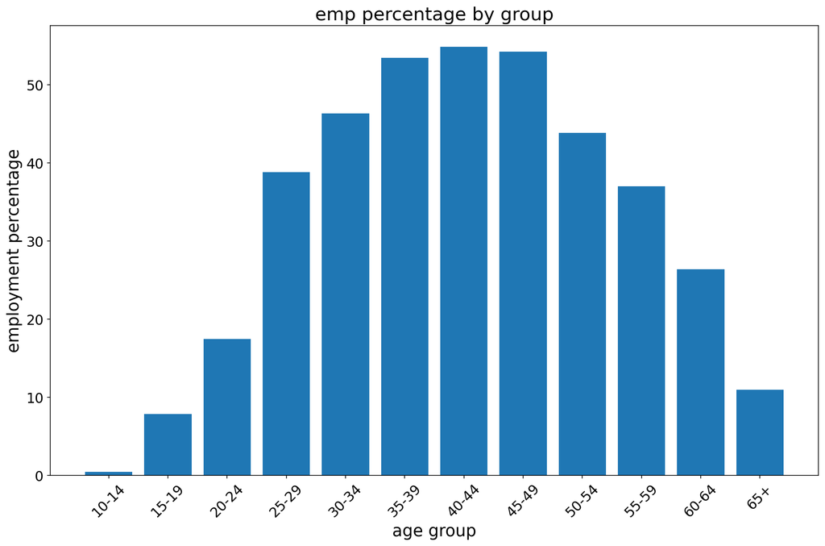

```python
plt.figure(figsize=(15,9),dpi=150)
plt.bar(list_age_groups,list_percentage_gorgan)
plt.title('emp percentage by group',size='20')
plt.xlabel('age group',size='18')
plt.ylabel('employment percentage',size='18')
plt.yticks(fontsize=15)
plt.xticks(fontsize=15)
plt.xticks(rotation=45)
plt.show()
```

# 1.4

با توجه به نمودار درصد جمعیت شاغل در گروه‌های سنی 35-39 ،40-44 و45-49 به اوج خود می‌رسد(به طور دقیق‌تر در گروه سنی 40-44) و در گروه سنی 50-54 این درصد کاهش چشمگیری می یابد.

```python
list_percentage_gorgan_urban=[]
list_age_groups=[]
for i in df['age_group']:
    list_percentage_gorgan_urban.append(round(df[df['settlement']=='شهري'][df[df['settlement']=='شهري']['age_group']==i].p_active_emp.sum()/df[df['settlement']=='شهري'][df[df['settlement']=='شهري']['age_group']==i].p_total.sum()*100,3))
    list_age_groups.append(i)
    if i == '65+':
        break
list_percentage_gorgan_urban
```

```
[0.363,
 5.753,
 15.096,
 38.541,
 46.355,
 54.395,
 55.774,
 54.836,
 43.226,
 34.48,
 22.169,
 8.37]
```

```python
list_percentage_gorgan_rural=[]
list_age_groups=[]
for i in df['age_group']:
    list_percentage_gorgan_rural.append(round(df[df['settlement']=='روستايي'][df[df['settlement']=='روستايي']['age_group']==i].p_active_emp.sum()/df[df['settlement']=='روستايي'][df[df['settlement']=='روستايي']['age_group']==i].p_total.sum()*100,3))
    list_age_groups.append(i)
    if i == '65+':
        break
list_percentage_gorgan_rural
```

```
[0.718,
 14.761,
 24.763,
 39.591,
 46.347,
 50.204,
 51.831,
 52.012,
 45.983,
 45.588,
 39.789,
 17.698]
```

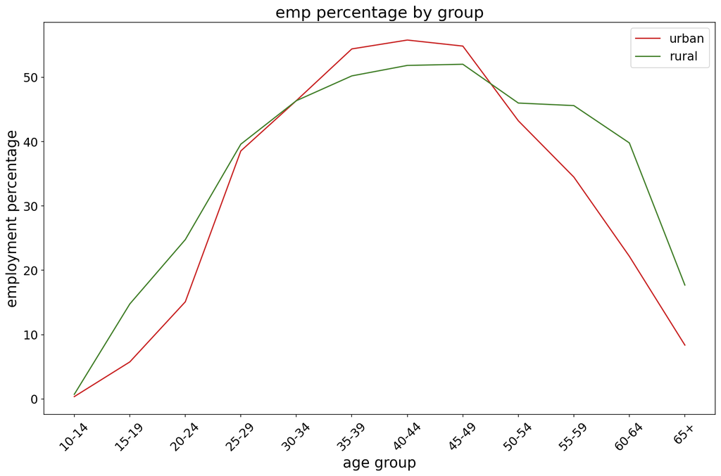

```python
plt.figure(figsize=(15,9),dpi=150)
plt.plot(list_age_groups,list_percentage_gorgan_urban,color='#c92525',label='urban')
plt.plot(list_age_groups,list_percentage_gorgan_rural,color='#43802b',label='rural')
plt.legend(fontsize='15')
plt.title('emp percentage by group',size='20')
plt.xlabel('age group',size='18')
plt.ylabel('employment percentage',size='18')
plt.yticks(fontsize=15)
plt.xticks(fontsize=15)
plt.xticks(rotation=45)
plt.show()
```

# 1.5

باتوجه به منحنی شاغلان شهری زودتر دست از کار می‌کشند (منحنی قرمز)

```python
list_percentage_gorgan_rural_men=[]
list_percentage_gorgan_rural_women=[]
list_age_groups=[]
for i in range(len(df['age_group'])):
    if df.gender.iloc[i]=='مرد':
        list_percentage_gorgan_rural_men.append(round(df[df['settlement']=='روستايي'][df[df['settlement']=='روستايي']['age_group']==df['age_group'][i]].p_active_emp.sum()/df[df['settlement']=='روستايي'][df[df['settlement']=='روستايي']['age_group']==df['age_group'][i]].p_total.sum()*100,3))


    elif df.gender.iloc[i]=='زن':
        list_percentage_gorgan_rural_women.append(round(df[df['settlement']=='روستايي'][df[df['settlement']=='روستايي']['age_group']==df['age_group'][i]].p_active_emp.sum()/df[df['settlement']=='روستايي'][df[df['settlement']=='روستايي']['age_group']==df['age_group'][i]].p_total.sum()*100,3))

    list_age_groups.append(df['age_group'][i])
    if df['age_group'][i] == '65+':
        break
list_percentage_gorgan_rural_men
```

```
[0.718,
 14.761,
 24.763,
 39.591,
 46.347,
 50.204,
 51.831,
 52.012,
 45.983,
 45.588,
 39.789,
 17.698]
```

```python
df_male_g=df[df['gender']=='مرد']
df_male_urban_g= df_male_g[df_male_g['settlement'] == 'شهري']
df_male_rural_g= df_male_g[df_male_g['settlement'] == 'روستايي']

df_female_g=df[df['gender']== 'زن']
df_female_urban_g= df_female_g[df_female_g['settlement'] == 'شهري']
df_female_rural_g= df_female_g[df_female_g['settlement'] == 'روستايي']

df_female_rural_g
```

|  | county_name | settlement | gender | age_group | p_active_emp | p_active_unemp | p_inactive_edu | p_inactive_homemaker | p_inactive_incomeNojob | p_inactive_other | p_not_stated | p_total | emp_ratio |
| --- | --- | --- | --- | --- | --- | --- | --- | --- | --- | --- | --- | --- | --- |
| 36 | گرگان | روستايي | زن | 10-14 | 16 | 5 | 3857 | 183 | 0 | 137 | 2 | 4200 | 0.003810 |
| 37 | گرگان | روستايي | زن | 15-19 | 156 | 65 | 1839 | 1215 | 3 | 223 | 3 | 3504 | 0.044521 |
| 38 | گرگان | روستايي | زن | 20-24 | 210 | 227 | 723 | 2700 | 4 | 260 | 15 | 4139 | 0.050737 |
| 39 | گرگان | روستايي | زن | 25-29 | 604 | 304 | 226 | 4254 | 6 | 96 | 12 | 5502 | 0.109778 |
| 40 | گرگان | روستايي | زن | 30-34 | 652 | 188 | 105 | 4620 | 8 | 90 | 15 | 5678 | 0.114829 |
| 41 | گرگان | روستايي | زن | 35-39 | 568 | 91 | 47 | 3851 | 11 | 71 | 26 | 4665 | 0.121758 |
| 42 | گرگان | روستايي | زن | 40-44 | 454 | 42 | 22 | 3365 | 16 | 70 | 10 | 3979 | 0.114099 |
| 43 | گرگان | روستايي | زن | 45-49 | 384 | 20 | 5 | 2747 | 29 | 29 | 9 | 3223 | 0.119144 |
| 44 | گرگان | روستايي | زن | 50-54 | 308 | 10 | 1 | 2572 | 59 | 16 | 5 | 2971 | 0.103669 |
| 45 | گرگان | روستايي | زن | 55-59 | 280 | 1 | 1 | 2040 | 91 | 5 | 6 | 2424 | 0.115512 |
| 46 | گرگان | روستايي | زن | 60-64 | 202 | 1 | 1 | 1672 | 102 | 2 | 3 | 1983 | 0.101866 |
| 47 | گرگان | روستايي | زن | 65+ | 216 | 0 | 3 | 2815 | 337 | 460 | 4 | 3835 | 0.056323 |

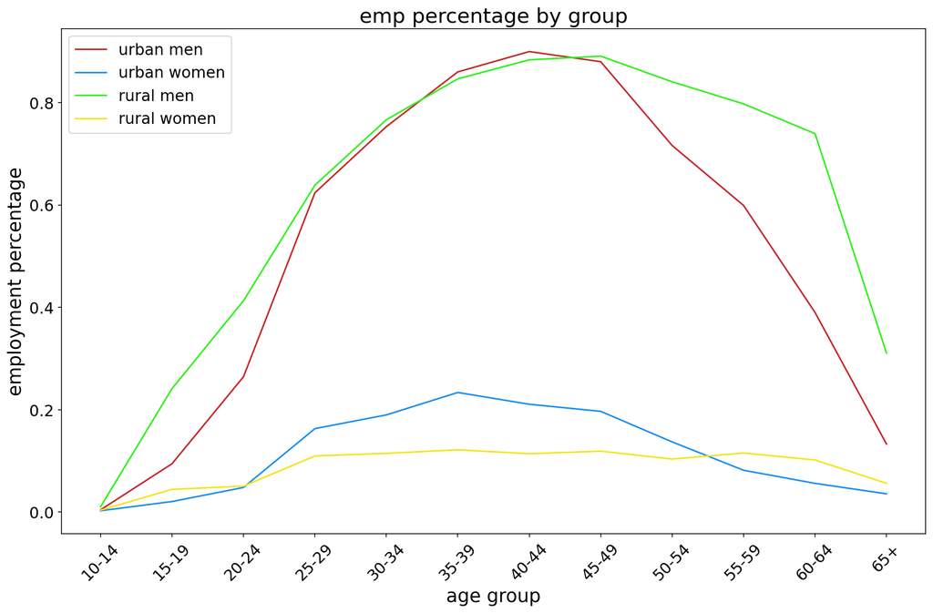

```python
plt.figure(figsize=(15,9),dpi=150)
plt.plot(list_age_groups,df_male_urban_g.emp_ratio,color='#c92525',label='urban men')
plt.plot(list_age_groups,df_female_urban_g.emp_ratio,color='#198ef2',label='urban women')
plt.plot(list_age_groups,df_male_rural_g.emp_ratio,color='#2df219',label='rural men')
plt.plot(list_age_groups,df_female_rural_g.emp_ratio,color='#f2e519',label='rural women')
plt.legend(fontsize='15')
plt.title('emp percentage by group',size='20')
plt.xlabel('age group',size='18')
plt.ylabel('employment percentage',size='18')
plt.yticks(fontsize=15)
plt.xticks(fontsize=15)
plt.xticks(rotation=45)
plt.show()
```

# 1.6

با مقایسه منحنی‌های قرمز و سبز باهم و همچنین زرد و آبی، هم زنان و هم مردان شاغل در شهر زودتر دست از کار می‌کشند

```python
pd.ExcelFile('data/1.xls').sheet_names
```

```
['تهران2301',
 'دماوند2302',
 'رئ2303',
 'شميرانات2304',
 'ورامين2306',
 'شهريار2309',
 'اسلامشهر2310',
 'رباطكريم2312',
 'پاكدشت2313',
 'فيروزكوه2314',
 'قدس2316',
 'ملارد2317',
 'پيشوا2318',
 'بهارستان2319',
 'پرديس2320',
 'قرچک2321']
```

```python
pd.ExcelFile('data/1.xls').sheet_names [0][:4:-1][::-1]
```

```
'2301'
```

```python
DF=pd.read_excel('data/1.xls')
DF
```

|  | Unnamed: 0 | Unnamed: 1 | Unnamed: 2 | Unnamed: 3 | Unnamed: 4 | Unnamed: 5 | Unnamed: 6 | Unnamed: 7 | Unnamed: 8 | Unnamed: 9 | Unnamed: 10 | Unnamed: 11 |
| --- | --- | --- | --- | --- | --- | --- | --- | --- | --- | --- | --- | --- |
| 0 | NaN | NaN | NaN | NaN | NaN | NaN | NaN | NaN | NaN | NaN | NaN | NaN |
| 1 | جدول 1- جمعيت 10 ساله و بيشتر بر حسب جنس، سن و... | NaN | NaN | NaN | NaN | NaN | NaN | NaN | NaN | NaN | NaN | NaN |
| 2 | NaN | NaN | NaN | NaN | NaN | NaN | NaN | NaN | NaN | NaN | NaN | NaN |
| 3 | جنس و سن | جمع | جمعيت فعال | NaN | NaN | جمعيت غير فعال | NaN | NaN | NaN | NaN | NaN | اظهار نشده |
| 4 | NaN | NaN | جمع | شاغل | بيكار | جمع | محصل | خانه دار | NaN | داراي درآمد بدون کار | ساير | NaN |
| 5 | مرد و زن | 7657493 | 2883904 | 2552476 | 331428 | 4765120 | 1394757 | 2175650 | NaN | 730139 | 464574 | 8469 |
| 6 | 10-14 ساله | 480339 | 1787 | 1720 | 67 | 478152 | 472825 | 1213 | NaN | 32 | 4082 | 400 |
| 7 | 15-19 ساله | 510353 | 42244 | 34359 | 7885 | 467571 | 418715 | 24181 | NaN | 193 | 24482 | 538 |
| 8 | 20-24 ساله | 589957 | 168112 | 116594 | 51518 | 420951 | 271576 | 91983 | NaN | 591 | 56801 | 894 |
| 9 | 25-29 ساله | 836754 | 469501 | 350479 | 119022 | 366042 | 111145 | 212902 | NaN | 1461 | 40534 | 1211 |
| 10 | 30-34 ساله | 1010331 | 576325 | 496161 | 80164 | 432852 | 58835 | 304388 | NaN | 2521 | 67108 | 1154 |
| 11 | 35-39 ساله | 841887 | 483676 | 443129 | 40547 | 357417 | 28853 | 278365 | NaN | 3458 | 46741 | 794 |
| 12 | 40-44 ساله | 643719 | 324568 | 309907 | 14661 | 318458 | 14829 | 224215 | NaN | 6980 | 72434 | 693 |
| 13 | 45-49 ساله | 617318 | 308671 | 299859 | 8812 | 307971 | 9861 | 225535 | NaN | 27161 | 45414 | 676 |
| 14 | 50-54 ساله | 547764 | 228990 | 224420 | 4570 | 318140 | 4963 | 213815 | NaN | 77560 | 21802 | 634 |
| 15 | 55-59 ساله | 470637 | 156943 | 154385 | 2558 | 313246 | 2060 | 188234 | NaN | 114933 | 8019 | 448 |
| 16 | 60-64 ساله | 374611 | 77767 | 76902 | 865 | 296512 | 708 | 142636 | NaN | 150642 | 2526 | 332 |
| 17 | 65 ساله و بيشتر | 733823 | 45320 | 44561 | 759 | 687808 | 387 | 268183 | NaN | 344607 | 74631 | 695 |
| 18 | مرد | 3792238 | 2244896 | 2046034 | 198862 | 1541611 | 680381 | 13219 | NaN | 540063 | 307948 | 5731 |
| 19 | 10-14 ساله | 245983 | 1360 | 1306 | 54 | 244420 | 241998 | 124 | NaN | 16 | 2282 | 203 |
| 20 | 15-19 ساله | 261400 | 35343 | 30154 | 5189 | 225739 | 210141 | 421 | NaN | 137 | 15040 | 318 |
| 21 | 20-24 ساله | 294780 | 125327 | 92864 | 32463 | 168994 | 129952 | 673 | NaN | 412 | 37957 | 459 |
| 22 | 25-29 ساله | 407604 | 332499 | 260337 | 72162 | 74347 | 49908 | 1140 | NaN | 850 | 22449 | 758 |
| 23 | 30-34 ساله | 491095 | 420022 | 375959 | 44063 | 70217 | 22762 | 1668 | NaN | 1373 | 44414 | 856 |
| 24 | 35-39 ساله | 413935 | 365902 | 342579 | 23323 | 47436 | 10908 | 1427 | NaN | 1892 | 33209 | 597 |
| 25 | 40-44 ساله | 321990 | 260065 | 251520 | 8545 | 61370 | 6299 | 1022 | NaN | 3750 | 50299 | 555 |
| 26 | 45-49 ساله | 308482 | 258619 | 252719 | 5900 | 49324 | 4525 | 880 | NaN | 16788 | 27131 | 539 |
| 27 | 50-54 ساله | 269795 | 197758 | 194227 | 3531 | 71540 | 2230 | 912 | NaN | 56723 | 11675 | 497 |
| 28 | 55-59 ساله | 228073 | 140045 | 137894 | 2151 | 87704 | 1020 | 989 | NaN | 81695 | 4000 | 324 |
| 29 | 60-64 ساله | 185429 | 69580 | 68807 | 773 | 115604 | 401 | 943 | NaN | 113287 | 973 | 245 |
| 30 | 65 ساله و بيشتر | 363672 | 38376 | 37668 | 708 | 324916 | 237 | 3020 | NaN | 263140 | 58519 | 380 |
| 31 | زن | 3865255 | 639008 | 506442 | 132566 | 3223509 | 714376 | 2162431 | NaN | 190076 | 156626 | 2738 |
| 32 | 10-14 ساله | 234356 | 427 | 414 | 13 | 233732 | 230827 | 1089 | NaN | 16 | 1800 | 197 |
| 33 | 15-19 ساله | 248953 | 6901 | 4205 | 2696 | 241832 | 208574 | 23760 | NaN | 56 | 9442 | 220 |
| 34 | 20-24 ساله | 295177 | 42785 | 23730 | 19055 | 251957 | 141624 | 91310 | NaN | 179 | 18844 | 435 |
| 35 | 25-29 ساله | 429150 | 137002 | 90142 | 46860 | 291695 | 61237 | 211762 | NaN | 611 | 18085 | 453 |
| 36 | 30-34 ساله | 519236 | 156303 | 120202 | 36101 | 362635 | 36073 | 302720 | NaN | 1148 | 22694 | 298 |
| 37 | 35-39 ساله | 427952 | 117774 | 100550 | 17224 | 309981 | 17945 | 276938 | NaN | 1566 | 13532 | 197 |
| 38 | 40-44 ساله | 321729 | 64503 | 58387 | 6116 | 257088 | 8530 | 223193 | NaN | 3230 | 22135 | 138 |
| 39 | 45-49 ساله | 308836 | 50052 | 47140 | 2912 | 258647 | 5336 | 224655 | NaN | 10373 | 18283 | 137 |
| 40 | 50-54 ساله | 277969 | 31232 | 30193 | 1039 | 246600 | 2733 | 212903 | NaN | 20837 | 10127 | 137 |
| 41 | 55-59 ساله | 242564 | 16898 | 16491 | 407 | 225542 | 1040 | 187245 | NaN | 33238 | 4019 | 124 |
| 42 | 60-64 ساله | 189182 | 8187 | 8095 | 92 | 180908 | 307 | 141693 | NaN | 37355 | 1553 | 87 |
| 43 | 65 ساله و بيشتر | 370151 | 6944 | 6893 | 51 | 362892 | 150 | 265163 | NaN | 81467 | 16112 | 315 |

وارد کردن فایل 1 (شهرستان تهران بخش شهری)

```python
DF.drop(list(range(0,18)),axis=0)
```

|  | Unnamed: 0 | Unnamed: 1 | Unnamed: 2 | Unnamed: 3 | Unnamed: 4 | Unnamed: 5 | Unnamed: 6 | Unnamed: 7 | Unnamed: 8 | Unnamed: 9 | Unnamed: 10 | Unnamed: 11 |
| --- | --- | --- | --- | --- | --- | --- | --- | --- | --- | --- | --- | --- |
| 18 | مرد | 3792238 | 2244896 | 2046034 | 198862 | 1541611 | 680381 | 13219 | NaN | 540063 | 307948 | 5731 |
| 19 | 10-14 ساله | 245983 | 1360 | 1306 | 54 | 244420 | 241998 | 124 | NaN | 16 | 2282 | 203 |
| 20 | 15-19 ساله | 261400 | 35343 | 30154 | 5189 | 225739 | 210141 | 421 | NaN | 137 | 15040 | 318 |
| 21 | 20-24 ساله | 294780 | 125327 | 92864 | 32463 | 168994 | 129952 | 673 | NaN | 412 | 37957 | 459 |
| 22 | 25-29 ساله | 407604 | 332499 | 260337 | 72162 | 74347 | 49908 | 1140 | NaN | 850 | 22449 | 758 |
| 23 | 30-34 ساله | 491095 | 420022 | 375959 | 44063 | 70217 | 22762 | 1668 | NaN | 1373 | 44414 | 856 |
| 24 | 35-39 ساله | 413935 | 365902 | 342579 | 23323 | 47436 | 10908 | 1427 | NaN | 1892 | 33209 | 597 |
| 25 | 40-44 ساله | 321990 | 260065 | 251520 | 8545 | 61370 | 6299 | 1022 | NaN | 3750 | 50299 | 555 |
| 26 | 45-49 ساله | 308482 | 258619 | 252719 | 5900 | 49324 | 4525 | 880 | NaN | 16788 | 27131 | 539 |
| 27 | 50-54 ساله | 269795 | 197758 | 194227 | 3531 | 71540 | 2230 | 912 | NaN | 56723 | 11675 | 497 |
| 28 | 55-59 ساله | 228073 | 140045 | 137894 | 2151 | 87704 | 1020 | 989 | NaN | 81695 | 4000 | 324 |
| 29 | 60-64 ساله | 185429 | 69580 | 68807 | 773 | 115604 | 401 | 943 | NaN | 113287 | 973 | 245 |
| 30 | 65 ساله و بيشتر | 363672 | 38376 | 37668 | 708 | 324916 | 237 | 3020 | NaN | 263140 | 58519 | 380 |
| 31 | زن | 3865255 | 639008 | 506442 | 132566 | 3223509 | 714376 | 2162431 | NaN | 190076 | 156626 | 2738 |
| 32 | 10-14 ساله | 234356 | 427 | 414 | 13 | 233732 | 230827 | 1089 | NaN | 16 | 1800 | 197 |
| 33 | 15-19 ساله | 248953 | 6901 | 4205 | 2696 | 241832 | 208574 | 23760 | NaN | 56 | 9442 | 220 |
| 34 | 20-24 ساله | 295177 | 42785 | 23730 | 19055 | 251957 | 141624 | 91310 | NaN | 179 | 18844 | 435 |
| 35 | 25-29 ساله | 429150 | 137002 | 90142 | 46860 | 291695 | 61237 | 211762 | NaN | 611 | 18085 | 453 |
| 36 | 30-34 ساله | 519236 | 156303 | 120202 | 36101 | 362635 | 36073 | 302720 | NaN | 1148 | 22694 | 298 |
| 37 | 35-39 ساله | 427952 | 117774 | 100550 | 17224 | 309981 | 17945 | 276938 | NaN | 1566 | 13532 | 197 |
| 38 | 40-44 ساله | 321729 | 64503 | 58387 | 6116 | 257088 | 8530 | 223193 | NaN | 3230 | 22135 | 138 |
| 39 | 45-49 ساله | 308836 | 50052 | 47140 | 2912 | 258647 | 5336 | 224655 | NaN | 10373 | 18283 | 137 |
| 40 | 50-54 ساله | 277969 | 31232 | 30193 | 1039 | 246600 | 2733 | 212903 | NaN | 20837 | 10127 | 137 |
| 41 | 55-59 ساله | 242564 | 16898 | 16491 | 407 | 225542 | 1040 | 187245 | NaN | 33238 | 4019 | 124 |
| 42 | 60-64 ساله | 189182 | 8187 | 8095 | 92 | 180908 | 307 | 141693 | NaN | 37355 | 1553 | 87 |
| 43 | 65 ساله و بيشتر | 370151 | 6944 | 6893 | 51 | 362892 | 150 | 265163 | NaN | 81467 | 16112 | 315 |

```python
DF=DF.drop(list(range(0,19)),axis=0)
DF=DF.drop([31],axis=0)
DF
```

|  | Unnamed: 0 | Unnamed: 1 | Unnamed: 2 | Unnamed: 3 | Unnamed: 4 | Unnamed: 5 | Unnamed: 6 | Unnamed: 7 | Unnamed: 8 | Unnamed: 9 | Unnamed: 10 | Unnamed: 11 |
| --- | --- | --- | --- | --- | --- | --- | --- | --- | --- | --- | --- | --- |
| 19 | 10-14 ساله | 245983 | 1360 | 1306 | 54 | 244420 | 241998 | 124 | NaN | 16 | 2282 | 203 |
| 20 | 15-19 ساله | 261400 | 35343 | 30154 | 5189 | 225739 | 210141 | 421 | NaN | 137 | 15040 | 318 |
| 21 | 20-24 ساله | 294780 | 125327 | 92864 | 32463 | 168994 | 129952 | 673 | NaN | 412 | 37957 | 459 |
| 22 | 25-29 ساله | 407604 | 332499 | 260337 | 72162 | 74347 | 49908 | 1140 | NaN | 850 | 22449 | 758 |
| 23 | 30-34 ساله | 491095 | 420022 | 375959 | 44063 | 70217 | 22762 | 1668 | NaN | 1373 | 44414 | 856 |
| 24 | 35-39 ساله | 413935 | 365902 | 342579 | 23323 | 47436 | 10908 | 1427 | NaN | 1892 | 33209 | 597 |
| 25 | 40-44 ساله | 321990 | 260065 | 251520 | 8545 | 61370 | 6299 | 1022 | NaN | 3750 | 50299 | 555 |
| 26 | 45-49 ساله | 308482 | 258619 | 252719 | 5900 | 49324 | 4525 | 880 | NaN | 16788 | 27131 | 539 |
| 27 | 50-54 ساله | 269795 | 197758 | 194227 | 3531 | 71540 | 2230 | 912 | NaN | 56723 | 11675 | 497 |
| 28 | 55-59 ساله | 228073 | 140045 | 137894 | 2151 | 87704 | 1020 | 989 | NaN | 81695 | 4000 | 324 |
| 29 | 60-64 ساله | 185429 | 69580 | 68807 | 773 | 115604 | 401 | 943 | NaN | 113287 | 973 | 245 |
| 30 | 65 ساله و بيشتر | 363672 | 38376 | 37668 | 708 | 324916 | 237 | 3020 | NaN | 263140 | 58519 | 380 |
| 32 | 10-14 ساله | 234356 | 427 | 414 | 13 | 233732 | 230827 | 1089 | NaN | 16 | 1800 | 197 |
| 33 | 15-19 ساله | 248953 | 6901 | 4205 | 2696 | 241832 | 208574 | 23760 | NaN | 56 | 9442 | 220 |
| 34 | 20-24 ساله | 295177 | 42785 | 23730 | 19055 | 251957 | 141624 | 91310 | NaN | 179 | 18844 | 435 |
| 35 | 25-29 ساله | 429150 | 137002 | 90142 | 46860 | 291695 | 61237 | 211762 | NaN | 611 | 18085 | 453 |
| 36 | 30-34 ساله | 519236 | 156303 | 120202 | 36101 | 362635 | 36073 | 302720 | NaN | 1148 | 22694 | 298 |
| 37 | 35-39 ساله | 427952 | 117774 | 100550 | 17224 | 309981 | 17945 | 276938 | NaN | 1566 | 13532 | 197 |
| 38 | 40-44 ساله | 321729 | 64503 | 58387 | 6116 | 257088 | 8530 | 223193 | NaN | 3230 | 22135 | 138 |
| 39 | 45-49 ساله | 308836 | 50052 | 47140 | 2912 | 258647 | 5336 | 224655 | NaN | 10373 | 18283 | 137 |
| 40 | 50-54 ساله | 277969 | 31232 | 30193 | 1039 | 246600 | 2733 | 212903 | NaN | 20837 | 10127 | 137 |
| 41 | 55-59 ساله | 242564 | 16898 | 16491 | 407 | 225542 | 1040 | 187245 | NaN | 33238 | 4019 | 124 |
| 42 | 60-64 ساله | 189182 | 8187 | 8095 | 92 | 180908 | 307 | 141693 | NaN | 37355 | 1553 | 87 |
| 43 | 65 ساله و بيشتر | 370151 | 6944 | 6893 | 51 | 362892 | 150 | 265163 | NaN | 81467 | 16112 | 315 |

```python
DF['gender']=1
DF
```

|  | Unnamed: 0 | Unnamed: 1 | Unnamed: 2 | Unnamed: 3 | Unnamed: 4 | Unnamed: 5 | Unnamed: 6 | Unnamed: 7 | Unnamed: 8 | Unnamed: 9 | Unnamed: 10 | Unnamed: 11 | gender |
| --- | --- | --- | --- | --- | --- | --- | --- | --- | --- | --- | --- | --- | --- |
| 19 | 10-14 ساله | 245983 | 1360 | 1306 | 54 | 244420 | 241998 | 124 | NaN | 16 | 2282 | 203 | 1 |
| 20 | 15-19 ساله | 261400 | 35343 | 30154 | 5189 | 225739 | 210141 | 421 | NaN | 137 | 15040 | 318 | 1 |
| 21 | 20-24 ساله | 294780 | 125327 | 92864 | 32463 | 168994 | 129952 | 673 | NaN | 412 | 37957 | 459 | 1 |
| 22 | 25-29 ساله | 407604 | 332499 | 260337 | 72162 | 74347 | 49908 | 1140 | NaN | 850 | 22449 | 758 | 1 |
| 23 | 30-34 ساله | 491095 | 420022 | 375959 | 44063 | 70217 | 22762 | 1668 | NaN | 1373 | 44414 | 856 | 1 |
| 24 | 35-39 ساله | 413935 | 365902 | 342579 | 23323 | 47436 | 10908 | 1427 | NaN | 1892 | 33209 | 597 | 1 |
| 25 | 40-44 ساله | 321990 | 260065 | 251520 | 8545 | 61370 | 6299 | 1022 | NaN | 3750 | 50299 | 555 | 1 |
| 26 | 45-49 ساله | 308482 | 258619 | 252719 | 5900 | 49324 | 4525 | 880 | NaN | 16788 | 27131 | 539 | 1 |
| 27 | 50-54 ساله | 269795 | 197758 | 194227 | 3531 | 71540 | 2230 | 912 | NaN | 56723 | 11675 | 497 | 1 |
| 28 | 55-59 ساله | 228073 | 140045 | 137894 | 2151 | 87704 | 1020 | 989 | NaN | 81695 | 4000 | 324 | 1 |
| 29 | 60-64 ساله | 185429 | 69580 | 68807 | 773 | 115604 | 401 | 943 | NaN | 113287 | 973 | 245 | 1 |
| 30 | 65 ساله و بيشتر | 363672 | 38376 | 37668 | 708 | 324916 | 237 | 3020 | NaN | 263140 | 58519 | 380 | 1 |
| 32 | 10-14 ساله | 234356 | 427 | 414 | 13 | 233732 | 230827 | 1089 | NaN | 16 | 1800 | 197 | 1 |
| 33 | 15-19 ساله | 248953 | 6901 | 4205 | 2696 | 241832 | 208574 | 23760 | NaN | 56 | 9442 | 220 | 1 |
| 34 | 20-24 ساله | 295177 | 42785 | 23730 | 19055 | 251957 | 141624 | 91310 | NaN | 179 | 18844 | 435 | 1 |
| 35 | 25-29 ساله | 429150 | 137002 | 90142 | 46860 | 291695 | 61237 | 211762 | NaN | 611 | 18085 | 453 | 1 |
| 36 | 30-34 ساله | 519236 | 156303 | 120202 | 36101 | 362635 | 36073 | 302720 | NaN | 1148 | 22694 | 298 | 1 |
| 37 | 35-39 ساله | 427952 | 117774 | 100550 | 17224 | 309981 | 17945 | 276938 | NaN | 1566 | 13532 | 197 | 1 |
| 38 | 40-44 ساله | 321729 | 64503 | 58387 | 6116 | 257088 | 8530 | 223193 | NaN | 3230 | 22135 | 138 | 1 |
| 39 | 45-49 ساله | 308836 | 50052 | 47140 | 2912 | 258647 | 5336 | 224655 | NaN | 10373 | 18283 | 137 | 1 |
| 40 | 50-54 ساله | 277969 | 31232 | 30193 | 1039 | 246600 | 2733 | 212903 | NaN | 20837 | 10127 | 137 | 1 |
| 41 | 55-59 ساله | 242564 | 16898 | 16491 | 407 | 225542 | 1040 | 187245 | NaN | 33238 | 4019 | 124 | 1 |
| 42 | 60-64 ساله | 189182 | 8187 | 8095 | 92 | 180908 | 307 | 141693 | NaN | 37355 | 1553 | 87 | 1 |
| 43 | 65 ساله و بيشتر | 370151 | 6944 | 6893 | 51 | 362892 | 150 | 265163 | NaN | 81467 | 16112 | 315 | 1 |

تعریف ستون جنسیت با مقدار دلخواه 1

```python
DF['gender'][0:12]='مرد'
DF['gender'][12:]='زن'
DF
```

|  | Unnamed: 0 | Unnamed: 1 | Unnamed: 2 | Unnamed: 3 | Unnamed: 4 | Unnamed: 5 | Unnamed: 6 | Unnamed: 7 | Unnamed: 8 | Unnamed: 9 | Unnamed: 10 | Unnamed: 11 | gender |
| --- | --- | --- | --- | --- | --- | --- | --- | --- | --- | --- | --- | --- | --- |
| 19 | 10-14 ساله | 245983 | 1360 | 1306 | 54 | 244420 | 241998 | 124 | NaN | 16 | 2282 | 203 | مرد |
| 20 | 15-19 ساله | 261400 | 35343 | 30154 | 5189 | 225739 | 210141 | 421 | NaN | 137 | 15040 | 318 | مرد |
| 21 | 20-24 ساله | 294780 | 125327 | 92864 | 32463 | 168994 | 129952 | 673 | NaN | 412 | 37957 | 459 | مرد |
| 22 | 25-29 ساله | 407604 | 332499 | 260337 | 72162 | 74347 | 49908 | 1140 | NaN | 850 | 22449 | 758 | مرد |
| 23 | 30-34 ساله | 491095 | 420022 | 375959 | 44063 | 70217 | 22762 | 1668 | NaN | 1373 | 44414 | 856 | مرد |
| 24 | 35-39 ساله | 413935 | 365902 | 342579 | 23323 | 47436 | 10908 | 1427 | NaN | 1892 | 33209 | 597 | مرد |
| 25 | 40-44 ساله | 321990 | 260065 | 251520 | 8545 | 61370 | 6299 | 1022 | NaN | 3750 | 50299 | 555 | مرد |
| 26 | 45-49 ساله | 308482 | 258619 | 252719 | 5900 | 49324 | 4525 | 880 | NaN | 16788 | 27131 | 539 | مرد |
| 27 | 50-54 ساله | 269795 | 197758 | 194227 | 3531 | 71540 | 2230 | 912 | NaN | 56723 | 11675 | 497 | مرد |
| 28 | 55-59 ساله | 228073 | 140045 | 137894 | 2151 | 87704 | 1020 | 989 | NaN | 81695 | 4000 | 324 | مرد |
| 29 | 60-64 ساله | 185429 | 69580 | 68807 | 773 | 115604 | 401 | 943 | NaN | 113287 | 973 | 245 | مرد |
| 30 | 65 ساله و بيشتر | 363672 | 38376 | 37668 | 708 | 324916 | 237 | 3020 | NaN | 263140 | 58519 | 380 | مرد |
| 32 | 10-14 ساله | 234356 | 427 | 414 | 13 | 233732 | 230827 | 1089 | NaN | 16 | 1800 | 197 | زن |
| 33 | 15-19 ساله | 248953 | 6901 | 4205 | 2696 | 241832 | 208574 | 23760 | NaN | 56 | 9442 | 220 | زن |
| 34 | 20-24 ساله | 295177 | 42785 | 23730 | 19055 | 251957 | 141624 | 91310 | NaN | 179 | 18844 | 435 | زن |
| 35 | 25-29 ساله | 429150 | 137002 | 90142 | 46860 | 291695 | 61237 | 211762 | NaN | 611 | 18085 | 453 | زن |
| 36 | 30-34 ساله | 519236 | 156303 | 120202 | 36101 | 362635 | 36073 | 302720 | NaN | 1148 | 22694 | 298 | زن |
| 37 | 35-39 ساله | 427952 | 117774 | 100550 | 17224 | 309981 | 17945 | 276938 | NaN | 1566 | 13532 | 197 | زن |
| 38 | 40-44 ساله | 321729 | 64503 | 58387 | 6116 | 257088 | 8530 | 223193 | NaN | 3230 | 22135 | 138 | زن |
| 39 | 45-49 ساله | 308836 | 50052 | 47140 | 2912 | 258647 | 5336 | 224655 | NaN | 10373 | 18283 | 137 | زن |
| 40 | 50-54 ساله | 277969 | 31232 | 30193 | 1039 | 246600 | 2733 | 212903 | NaN | 20837 | 10127 | 137 | زن |
| 41 | 55-59 ساله | 242564 | 16898 | 16491 | 407 | 225542 | 1040 | 187245 | NaN | 33238 | 4019 | 124 | زن |
| 42 | 60-64 ساله | 189182 | 8187 | 8095 | 92 | 180908 | 307 | 141693 | NaN | 37355 | 1553 | 87 | زن |
| 43 | 65 ساله و بيشتر | 370151 | 6944 | 6893 | 51 | 362892 | 150 | 265163 | NaN | 81467 | 16112 | 315 | زن |

تعیین جنسیت گروه ها

```python
DF=DF.drop(columns=['Unnamed: 8','Unnamed: 1','Unnamed: 2','Unnamed: 5'])
DF
```

|  | Unnamed: 0 | Unnamed: 3 | Unnamed: 4 | Unnamed: 6 | Unnamed: 7 | Unnamed: 9 | Unnamed: 10 | Unnamed: 11 | gender |
| --- | --- | --- | --- | --- | --- | --- | --- | --- | --- |
| 19 | 10-14 ساله | 1306 | 54 | 241998 | 124 | 16 | 2282 | 203 | مرد |
| 20 | 15-19 ساله | 30154 | 5189 | 210141 | 421 | 137 | 15040 | 318 | مرد |
| 21 | 20-24 ساله | 92864 | 32463 | 129952 | 673 | 412 | 37957 | 459 | مرد |
| 22 | 25-29 ساله | 260337 | 72162 | 49908 | 1140 | 850 | 22449 | 758 | مرد |
| 23 | 30-34 ساله | 375959 | 44063 | 22762 | 1668 | 1373 | 44414 | 856 | مرد |
| 24 | 35-39 ساله | 342579 | 23323 | 10908 | 1427 | 1892 | 33209 | 597 | مرد |
| 25 | 40-44 ساله | 251520 | 8545 | 6299 | 1022 | 3750 | 50299 | 555 | مرد |
| 26 | 45-49 ساله | 252719 | 5900 | 4525 | 880 | 16788 | 27131 | 539 | مرد |
| 27 | 50-54 ساله | 194227 | 3531 | 2230 | 912 | 56723 | 11675 | 497 | مرد |
| 28 | 55-59 ساله | 137894 | 2151 | 1020 | 989 | 81695 | 4000 | 324 | مرد |
| 29 | 60-64 ساله | 68807 | 773 | 401 | 943 | 113287 | 973 | 245 | مرد |
| 30 | 65 ساله و بيشتر | 37668 | 708 | 237 | 3020 | 263140 | 58519 | 380 | مرد |
| 32 | 10-14 ساله | 414 | 13 | 230827 | 1089 | 16 | 1800 | 197 | زن |
| 33 | 15-19 ساله | 4205 | 2696 | 208574 | 23760 | 56 | 9442 | 220 | زن |
| 34 | 20-24 ساله | 23730 | 19055 | 141624 | 91310 | 179 | 18844 | 435 | زن |
| 35 | 25-29 ساله | 90142 | 46860 | 61237 | 211762 | 611 | 18085 | 453 | زن |
| 36 | 30-34 ساله | 120202 | 36101 | 36073 | 302720 | 1148 | 22694 | 298 | زن |
| 37 | 35-39 ساله | 100550 | 17224 | 17945 | 276938 | 1566 | 13532 | 197 | زن |
| 38 | 40-44 ساله | 58387 | 6116 | 8530 | 223193 | 3230 | 22135 | 138 | زن |
| 39 | 45-49 ساله | 47140 | 2912 | 5336 | 224655 | 10373 | 18283 | 137 | زن |
| 40 | 50-54 ساله | 30193 | 1039 | 2733 | 212903 | 20837 | 10127 | 137 | زن |
| 41 | 55-59 ساله | 16491 | 407 | 1040 | 187245 | 33238 | 4019 | 124 | زن |
| 42 | 60-64 ساله | 8095 | 92 | 307 | 141693 | 37355 | 1553 | 87 | زن |
| 43 | 65 ساله و بيشتر | 6893 | 51 | 150 | 265163 | 81467 | 16112 | 315 | زن |

حذف ستون های اضافی

```python
temp_cols=DF.columns.tolist()
new_cols=[temp_cols[-1]]
new_cols=new_cols+(temp_cols[0:-1])
DF=DF[new_cols]
DF
```

|  | gender | Unnamed: 0 | Unnamed: 3 | Unnamed: 4 | Unnamed: 6 | Unnamed: 7 | Unnamed: 9 | Unnamed: 10 | Unnamed: 11 |
| --- | --- | --- | --- | --- | --- | --- | --- | --- | --- |
| 19 | مرد | 10-14 ساله | 1306 | 54 | 241998 | 124 | 16 | 2282 | 203 |
| 20 | مرد | 15-19 ساله | 30154 | 5189 | 210141 | 421 | 137 | 15040 | 318 |
| 21 | مرد | 20-24 ساله | 92864 | 32463 | 129952 | 673 | 412 | 37957 | 459 |
| 22 | مرد | 25-29 ساله | 260337 | 72162 | 49908 | 1140 | 850 | 22449 | 758 |
| 23 | مرد | 30-34 ساله | 375959 | 44063 | 22762 | 1668 | 1373 | 44414 | 856 |
| 24 | مرد | 35-39 ساله | 342579 | 23323 | 10908 | 1427 | 1892 | 33209 | 597 |
| 25 | مرد | 40-44 ساله | 251520 | 8545 | 6299 | 1022 | 3750 | 50299 | 555 |
| 26 | مرد | 45-49 ساله | 252719 | 5900 | 4525 | 880 | 16788 | 27131 | 539 |
| 27 | مرد | 50-54 ساله | 194227 | 3531 | 2230 | 912 | 56723 | 11675 | 497 |
| 28 | مرد | 55-59 ساله | 137894 | 2151 | 1020 | 989 | 81695 | 4000 | 324 |
| 29 | مرد | 60-64 ساله | 68807 | 773 | 401 | 943 | 113287 | 973 | 245 |
| 30 | مرد | 65 ساله و بيشتر | 37668 | 708 | 237 | 3020 | 263140 | 58519 | 380 |
| 32 | زن | 10-14 ساله | 414 | 13 | 230827 | 1089 | 16 | 1800 | 197 |
| 33 | زن | 15-19 ساله | 4205 | 2696 | 208574 | 23760 | 56 | 9442 | 220 |
| 34 | زن | 20-24 ساله | 23730 | 19055 | 141624 | 91310 | 179 | 18844 | 435 |
| 35 | زن | 25-29 ساله | 90142 | 46860 | 61237 | 211762 | 611 | 18085 | 453 |
| 36 | زن | 30-34 ساله | 120202 | 36101 | 36073 | 302720 | 1148 | 22694 | 298 |
| 37 | زن | 35-39 ساله | 100550 | 17224 | 17945 | 276938 | 1566 | 13532 | 197 |
| 38 | زن | 40-44 ساله | 58387 | 6116 | 8530 | 223193 | 3230 | 22135 | 138 |
| 39 | زن | 45-49 ساله | 47140 | 2912 | 5336 | 224655 | 10373 | 18283 | 137 |
| 40 | زن | 50-54 ساله | 30193 | 1039 | 2733 | 212903 | 20837 | 10127 | 137 |
| 41 | زن | 55-59 ساله | 16491 | 407 | 1040 | 187245 | 33238 | 4019 | 124 |
| 42 | زن | 60-64 ساله | 8095 | 92 | 307 | 141693 | 37355 | 1553 | 87 |
| 43 | زن | 65 ساله و بيشتر | 6893 | 51 | 150 | 265163 | 81467 | 16112 | 315 |

انتقال ستون آخر دیتا فریم به اول

```python
def order(DF):
    temp_cols=DF.columns.tolist()
    new_cols=[temp_cols[-1]]
    new_cols=new_cols+(temp_cols[0:-1])
    DF=DF[new_cols]
    return DF
```

تابعی برای انتقال ستون آخر دیتا فریم به اول آن

```python
#یافتن نام شیت های فایل اول
pd.ExcelFile('data/1.xls').sheet_names
```

```
['تهران2301',
 'دماوند2302',
 'رئ2303',
 'شميرانات2304',
 'ورامين2306',
 'شهريار2309',
 'اسلامشهر2310',
 'رباطكريم2312',
 'پاكدشت2313',
 'فيروزكوه2314',
 'قدس2316',
 'ملارد2317',
 'پيشوا2318',
 'بهارستان2319',
 'پرديس2320',
 'قرچک2321']
```

```python
L=[]
sheets=pd.ExcelFile('data/1.xls').sheet_names
for j in range(len(sheets)):
    DF1=(pd.read_excel('data/1.xls',sheet_name=sheets[j]))
    if j==0:
        DF1=DF1.drop(list(range(0,19)),axis=0)
        DF1=DF1.drop([31],axis=0)
    else:
        DF1=DF1.drop(list(range(0,18)),axis=0)
        DF1=DF1.drop([30],axis=0)
    DF1['gender']=1
    DF1['gender'][0:12]='مرد'
    DF1['gender'][12:]='زن'
    DF1=DF1.drop(columns=['Unnamed: 8','Unnamed: 1','Unnamed: 2','Unnamed: 5'])
    DF1=order(DF1)
    DF1['county_id']=sheets[j][::-1][0:4][::-1]
    DF1['county_name']=sheets[j][::-1][4:][::-1]
    L.append(DF1)
DF1=pd.concat(L)
DF1.head(30)
```

|  | gender | Unnamed: 0 | Unnamed: 3 | Unnamed: 4 | Unnamed: 6 | Unnamed: 7 | Unnamed: 9 | Unnamed: 10 | Unnamed: 11 | county_id | county_name |
| --- | --- | --- | --- | --- | --- | --- | --- | --- | --- | --- | --- |
| 19 | مرد | 10-14 ساله | 1306 | 54 | 241998 | 124 | 16 | 2282 | 203 | 2301 | تهران |
| 20 | مرد | 15-19 ساله | 30154 | 5189 | 210141 | 421 | 137 | 15040 | 318 | 2301 | تهران |
| 21 | مرد | 20-24 ساله | 92864 | 32463 | 129952 | 673 | 412 | 37957 | 459 | 2301 | تهران |
| 22 | مرد | 25-29 ساله | 260337 | 72162 | 49908 | 1140 | 850 | 22449 | 758 | 2301 | تهران |
| 23 | مرد | 30-34 ساله | 375959 | 44063 | 22762 | 1668 | 1373 | 44414 | 856 | 2301 | تهران |
| 24 | مرد | 35-39 ساله | 342579 | 23323 | 10908 | 1427 | 1892 | 33209 | 597 | 2301 | تهران |
| 25 | مرد | 40-44 ساله | 251520 | 8545 | 6299 | 1022 | 3750 | 50299 | 555 | 2301 | تهران |
| 26 | مرد | 45-49 ساله | 252719 | 5900 | 4525 | 880 | 16788 | 27131 | 539 | 2301 | تهران |
| 27 | مرد | 50-54 ساله | 194227 | 3531 | 2230 | 912 | 56723 | 11675 | 497 | 2301 | تهران |
| 28 | مرد | 55-59 ساله | 137894 | 2151 | 1020 | 989 | 81695 | 4000 | 324 | 2301 | تهران |
| 29 | مرد | 60-64 ساله | 68807 | 773 | 401 | 943 | 113287 | 973 | 245 | 2301 | تهران |
| 30 | مرد | 65 ساله و بيشتر | 37668 | 708 | 237 | 3020 | 263140 | 58519 | 380 | 2301 | تهران |
| 32 | زن | 10-14 ساله | 414 | 13 | 230827 | 1089 | 16 | 1800 | 197 | 2301 | تهران |
| 33 | زن | 15-19 ساله | 4205 | 2696 | 208574 | 23760 | 56 | 9442 | 220 | 2301 | تهران |
| 34 | زن | 20-24 ساله | 23730 | 19055 | 141624 | 91310 | 179 | 18844 | 435 | 2301 | تهران |
| 35 | زن | 25-29 ساله | 90142 | 46860 | 61237 | 211762 | 611 | 18085 | 453 | 2301 | تهران |
| 36 | زن | 30-34 ساله | 120202 | 36101 | 36073 | 302720 | 1148 | 22694 | 298 | 2301 | تهران |
| 37 | زن | 35-39 ساله | 100550 | 17224 | 17945 | 276938 | 1566 | 13532 | 197 | 2301 | تهران |
| 38 | زن | 40-44 ساله | 58387 | 6116 | 8530 | 223193 | 3230 | 22135 | 138 | 2301 | تهران |
| 39 | زن | 45-49 ساله | 47140 | 2912 | 5336 | 224655 | 10373 | 18283 | 137 | 2301 | تهران |
| 40 | زن | 50-54 ساله | 30193 | 1039 | 2733 | 212903 | 20837 | 10127 | 137 | 2301 | تهران |
| 41 | زن | 55-59 ساله | 16491 | 407 | 1040 | 187245 | 33238 | 4019 | 124 | 2301 | تهران |
| 42 | زن | 60-64 ساله | 8095 | 92 | 307 | 141693 | 37355 | 1553 | 87 | 2301 | تهران |
| 43 | زن | 65 ساله و بيشتر | 6893 | 51 | 150 | 265163 | 81467 | 16112 | 315 | 2301 | تهران |
| 18 | مرد | 10-14 ساله | 23 | 2 | 3362 | 9 | NaN | 58 | 1 | 2302 | دماوند |
| 19 | مرد | 15-19 ساله | 561 | 42 | 2442 | 22 | 3 | 210 | NaN | 2302 | دماوند |
| 20 | مرد | 20-24 ساله | 1381 | 303 | 1096 | 23 | 7 | 491 | 1 | 2302 | دماوند |
| 21 | مرد | 25-29 ساله | 2953 | 542 | 382 | 32 | 8 | 300 | NaN | 2302 | دماوند |
| 22 | مرد | 30-34 ساله | 4072 | 232 | 168 | 29 | 16 | 518 | NaN | 2302 | دماوند |
| 23 | مرد | 35-39 ساله | 3677 | 116 | 100 | 24 | 13 | 397 | 2 | 2302 | دماوند |

وارد کردن شیت های فایل 1 و مرتب کردن و چسباندن آنها به هم

```python
def ordered_sheets(Adress):
    L=[]
    sheets=pd.ExcelFile(Adress).sheet_names
    for j in range(len(sheets)):
        DF1=(pd.read_excel(Adress,sheet_name=sheets[j]))
        if j==0:
            DF1=DF1.drop(list(range(0,19)),axis=0)
            DF1=DF1.drop([31],axis=0)
        else:
            DF1=DF1.drop(list(range(0,18)),axis=0)
            DF1=DF1.drop([30],axis=0)

        DF1['gender']=1
        DF1['gender'][0:12]='مرد'
        DF1['gender'][12:]='زن'
        DF1=DF1.drop(columns=['Unnamed: 8','Unnamed: 1','Unnamed: 2','Unnamed: 5'])
        DF1=order(DF1)
        DF1['county_id']=sheets[j][::-1][0:4][::-1]
        DF1['county_name']=sheets[j][::-1][4:][::-1]
        L.append(DF1)
    DF1=pd.concat(L)
    return DF1
```

تابعی برای مرتب کردن شیت های فایل اکسل (که همان شهرستانها هستند) و چسباندن آنها به هم

```python
DF1['settlement']='شهری'
DF1
```

|  | gender | Unnamed: 0 | Unnamed: 3 | Unnamed: 4 | Unnamed: 6 | Unnamed: 7 | Unnamed: 9 | Unnamed: 10 | Unnamed: 11 | county_id | county_name | settlement |
| --- | --- | --- | --- | --- | --- | --- | --- | --- | --- | --- | --- | --- |
| 19 | مرد | 10-14 ساله | 1306 | 54 | 241998 | 124 | 16 | 2282 | 203 | 2301 | تهران | شهری |
| 20 | مرد | 15-19 ساله | 30154 | 5189 | 210141 | 421 | 137 | 15040 | 318 | 2301 | تهران | شهری |
| 21 | مرد | 20-24 ساله | 92864 | 32463 | 129952 | 673 | 412 | 37957 | 459 | 2301 | تهران | شهری |
| 22 | مرد | 25-29 ساله | 260337 | 72162 | 49908 | 1140 | 850 | 22449 | 758 | 2301 | تهران | شهری |
| 23 | مرد | 30-34 ساله | 375959 | 44063 | 22762 | 1668 | 1373 | 44414 | 856 | 2301 | تهران | شهری |
| ... | ... | ... | ... | ... | ... | ... | ... | ... | ... | ... | ... | ... |
| 38 | زن | 45-49 ساله | 340 | 11 | 25 | 5486 | 95 | 184 | 2 | 2321 | قرچک | شهری |
| 39 | زن | 50-54 ساله | 190 | 2 | 2 | 4459 | 141 | 89 | 2 | 2321 | قرچک | شهری |
| 40 | زن | 55-59 ساله | 84 | NaN | 2 | 3553 | 187 | 64 | 5 | 2321 | قرچک | شهری |
| 41 | زن | 60-64 ساله | 100 | NaN | NaN | 2540 | 223 | 28 | NaN | 2321 | قرچک | شهری |
| 42 | زن | 65 ساله و بيشتر | 120 | NaN | NaN | 3439 | 526 | 259 | 5 | 2321 | قرچک | شهری |

384 rows × 12 columns

تعیین وضعیت شهری برای فایل 1

فایل های فرد شهری و فایل های زوج آمار بخش روستایی هستند

```python
list_DF=[DF1]
for i in range(2,63):
    DFi=ordered_sheets(f'data/{i}.xls')
    DFi=order(DFi)
    if i%2==1:
        DFi['settlement']='شهری'
    else:
        DFi['settlement']='روستایی'
    list_DF.append(DFi)
DF=pd.concat(list_DF)
DF
```

|  | gender | Unnamed: 0 | Unnamed: 3 | Unnamed: 4 | Unnamed: 6 | Unnamed: 7 | Unnamed: 9 | Unnamed: 10 | Unnamed: 11 | county_id | county_name | settlement |
| --- | --- | --- | --- | --- | --- | --- | --- | --- | --- | --- | --- | --- |
| 19 | مرد | 10-14 ساله | 1306 | 54 | 241998 | 124 | 16 | 2282 | 203 | 2301 | تهران | شهری |
| 20 | مرد | 15-19 ساله | 30154 | 5189 | 210141 | 421 | 137 | 15040 | 318 | 2301 | تهران | شهری |
| 21 | مرد | 20-24 ساله | 92864 | 32463 | 129952 | 673 | 412 | 37957 | 459 | 2301 | تهران | شهری |
| 22 | مرد | 25-29 ساله | 260337 | 72162 | 49908 | 1140 | 850 | 22449 | 758 | 2301 | تهران | شهری |
| 23 | مرد | 30-34 ساله | 375959 | 44063 | 22762 | 1668 | 1373 | 44414 | 856 | 2301 | تهران | شهری |
| ... | ... | ... | ... | ... | ... | ... | ... | ... | ... | ... | ... | ... |
| 38 | زن | 45-49 ساله | 95 | NaN | 1 | 155 | NaN | 7 | NaN | 1708 | لنده | روستایی |
| 39 | زن | 50-54 ساله | 69 | NaN | NaN | 114 | 2 | 2 | NaN | 1708 | لنده | روستایی |
| 40 | زن | 55-59 ساله | 71 | NaN | NaN | 97 | NaN | 6 | NaN | 1708 | لنده | روستایی |
| 41 | زن | 60-64 ساله | 74 | NaN | NaN | 89 | 1 | NaN | NaN | 1708 | لنده | روستایی |
| 42 | زن | 65 ساله و بيشتر | 73 | NaN | NaN | 166 | 2 | 84 | NaN | 1708 | لنده | روستایی |

20592 rows × 12 columns

وارد کردن تمامی فایل های آماری با تعیین اسم و کد شهرستان و وضعیت شهری و روستایی بودن آن ها

```python
DF=DF.reset_index()
DF=DF.drop(columns=['index'])
for i in range(0,3):
    DF=order(DF)
DF
```

|  | county_id | county_name | settlement | gender | Unnamed: 0 | Unnamed: 3 | Unnamed: 4 | Unnamed: 6 | Unnamed: 7 | Unnamed: 9 | Unnamed: 10 | Unnamed: 11 |
| --- | --- | --- | --- | --- | --- | --- | --- | --- | --- | --- | --- | --- |
| 0 | 2301 | تهران | شهری | مرد | 10-14 ساله | 1306 | 54 | 241998 | 124 | 16 | 2282 | 203 |
| 1 | 2301 | تهران | شهری | مرد | 15-19 ساله | 30154 | 5189 | 210141 | 421 | 137 | 15040 | 318 |
| 2 | 2301 | تهران | شهری | مرد | 20-24 ساله | 92864 | 32463 | 129952 | 673 | 412 | 37957 | 459 |
| 3 | 2301 | تهران | شهری | مرد | 25-29 ساله | 260337 | 72162 | 49908 | 1140 | 850 | 22449 | 758 |
| 4 | 2301 | تهران | شهری | مرد | 30-34 ساله | 375959 | 44063 | 22762 | 1668 | 1373 | 44414 | 856 |
| ... | ... | ... | ... | ... | ... | ... | ... | ... | ... | ... | ... | ... |
| 20587 | 1708 | لنده | روستایی | زن | 45-49 ساله | 95 | NaN | 1 | 155 | NaN | 7 | NaN |
| 20588 | 1708 | لنده | روستایی | زن | 50-54 ساله | 69 | NaN | NaN | 114 | 2 | 2 | NaN |
| 20589 | 1708 | لنده | روستایی | زن | 55-59 ساله | 71 | NaN | NaN | 97 | NaN | 6 | NaN |
| 20590 | 1708 | لنده | روستایی | زن | 60-64 ساله | 74 | NaN | NaN | 89 | 1 | NaN | NaN |
| 20591 | 1708 | لنده | روستایی | زن | 65 ساله و بيشتر | 73 | NaN | NaN | 166 | 2 | 84 | NaN |

20592 rows × 12 columns

مرتب کردن ایندکس ها و تعیین ترتیب ستون ها

```python
DF.columns = ["county_id",
              "county_name",
              "settlement",
              "gender",
              "age_group",
              "p_active_emp",
              "p_active_unemp",
              "p_inactive_edu",
              "p_inactive_homemaker",
              "p_inactive_incomeNojob",
              "p_inactive_other",
              "p_not_stated"
              ]
DF
```

|  | county_id | county_name | settlement | gender | age_group | p_active_emp | p_active_unemp | p_inactive_edu | p_inactive_homemaker | p_inactive_incomeNojob | p_inactive_other | p_not_stated |
| --- | --- | --- | --- | --- | --- | --- | --- | --- | --- | --- | --- | --- |
| 0 | 2301 | تهران | شهری | مرد | 10-14 ساله | 1306 | 54 | 241998 | 124 | 16 | 2282 | 203 |
| 1 | 2301 | تهران | شهری | مرد | 15-19 ساله | 30154 | 5189 | 210141 | 421 | 137 | 15040 | 318 |
| 2 | 2301 | تهران | شهری | مرد | 20-24 ساله | 92864 | 32463 | 129952 | 673 | 412 | 37957 | 459 |
| 3 | 2301 | تهران | شهری | مرد | 25-29 ساله | 260337 | 72162 | 49908 | 1140 | 850 | 22449 | 758 |
| 4 | 2301 | تهران | شهری | مرد | 30-34 ساله | 375959 | 44063 | 22762 | 1668 | 1373 | 44414 | 856 |
| ... | ... | ... | ... | ... | ... | ... | ... | ... | ... | ... | ... | ... |
| 20587 | 1708 | لنده | روستایی | زن | 45-49 ساله | 95 | NaN | 1 | 155 | NaN | 7 | NaN |
| 20588 | 1708 | لنده | روستایی | زن | 50-54 ساله | 69 | NaN | NaN | 114 | 2 | 2 | NaN |
| 20589 | 1708 | لنده | روستایی | زن | 55-59 ساله | 71 | NaN | NaN | 97 | NaN | 6 | NaN |
| 20590 | 1708 | لنده | روستایی | زن | 60-64 ساله | 74 | NaN | NaN | 89 | 1 | NaN | NaN |
| 20591 | 1708 | لنده | روستایی | زن | 65 ساله و بيشتر | 73 | NaN | NaN | 166 | 2 | 84 | NaN |

20592 rows × 12 columns

تغییر نام ستون ها به نام های خواسته شده

```python
DF=DF.replace(np.nan,0)
DF
```

|  | county_id | county_name | settlement | gender | age_group | p_active_emp | p_active_unemp | p_inactive_edu | p_inactive_homemaker | p_inactive_incomeNojob | p_inactive_other | p_not_stated |
| --- | --- | --- | --- | --- | --- | --- | --- | --- | --- | --- | --- | --- |
| 0 | 2301 | تهران | شهری | مرد | 10-14 ساله | 1306 | 54 | 241998 | 124 | 16 | 2282 | 203 |
| 1 | 2301 | تهران | شهری | مرد | 15-19 ساله | 30154 | 5189 | 210141 | 421 | 137 | 15040 | 318 |
| 2 | 2301 | تهران | شهری | مرد | 20-24 ساله | 92864 | 32463 | 129952 | 673 | 412 | 37957 | 459 |
| 3 | 2301 | تهران | شهری | مرد | 25-29 ساله | 260337 | 72162 | 49908 | 1140 | 850 | 22449 | 758 |
| 4 | 2301 | تهران | شهری | مرد | 30-34 ساله | 375959 | 44063 | 22762 | 1668 | 1373 | 44414 | 856 |
| ... | ... | ... | ... | ... | ... | ... | ... | ... | ... | ... | ... | ... |
| 20587 | 1708 | لنده | روستایی | زن | 45-49 ساله | 95 | 0 | 1 | 155 | 0 | 7 | 0 |
| 20588 | 1708 | لنده | روستایی | زن | 50-54 ساله | 69 | 0 | 0 | 114 | 2 | 2 | 0 |
| 20589 | 1708 | لنده | روستایی | زن | 55-59 ساله | 71 | 0 | 0 | 97 | 0 | 6 | 0 |
| 20590 | 1708 | لنده | روستایی | زن | 60-64 ساله | 74 | 0 | 0 | 89 | 1 | 0 | 0 |
| 20591 | 1708 | لنده | روستایی | زن | 65 ساله و بيشتر | 73 | 0 | 0 | 166 | 2 | 84 | 0 |

20592 rows × 12 columns

convert nan to 0

مقادیر خالی به این معنا بوده که آمارگیر نتوانسته است شخصی با این مشخصات بیابد پس میتوان مقدار 0 را به آنها نسبت داد

```python
DF['emp_ratio']=DF['p_active_emp']/(DF['p_active_emp']+DF['p_inactive_edu']+DF['p_inactive_homemaker']+DF['p_inactive_incomeNojob']+DF['p_inactive_other']+DF['p_not_stated'])
DF
```

|  | county_id | county_name | settlement | gender | age_group | p_active_emp | p_active_unemp | p_inactive_edu | p_inactive_homemaker | p_inactive_incomeNojob | p_inactive_other | p_not_stated | emp_ratio |
| --- | --- | --- | --- | --- | --- | --- | --- | --- | --- | --- | --- | --- | --- |
| 0 | 2301 | تهران | شهری | مرد | 10-14 ساله | 1306 | 54 | 241998 | 124 | 16 | 2282 | 203 | 0.005310 |
| 1 | 2301 | تهران | شهری | مرد | 15-19 ساله | 30154 | 5189 | 210141 | 421 | 137 | 15040 | 318 | 0.117692 |
| 2 | 2301 | تهران | شهری | مرد | 20-24 ساله | 92864 | 32463 | 129952 | 673 | 412 | 37957 | 459 | 0.354014 |
| 3 | 2301 | تهران | شهری | مرد | 25-29 ساله | 260337 | 72162 | 49908 | 1140 | 850 | 22449 | 758 | 0.776101 |
| 4 | 2301 | تهران | شهری | مرد | 30-34 ساله | 375959 | 44063 | 22762 | 1668 | 1373 | 44414 | 856 | 0.841011 |
| ... | ... | ... | ... | ... | ... | ... | ... | ... | ... | ... | ... | ... | ... |
| 20587 | 1708 | لنده | روستایی | زن | 45-49 ساله | 95 | 0 | 1 | 155 | 0 | 7 | 0 | 0.368217 |
| 20588 | 1708 | لنده | روستایی | زن | 50-54 ساله | 69 | 0 | 0 | 114 | 2 | 2 | 0 | 0.368984 |
| 20589 | 1708 | لنده | روستایی | زن | 55-59 ساله | 71 | 0 | 0 | 97 | 0 | 6 | 0 | 0.408046 |
| 20590 | 1708 | لنده | روستایی | زن | 60-64 ساله | 74 | 0 | 0 | 89 | 1 | 0 | 0 | 0.451220 |
| 20591 | 1708 | لنده | روستایی | زن | 65 ساله و بيشتر | 73 | 0 | 0 | 166 | 2 | 84 | 0 | 0.224615 |

20592 rows × 13 columns

تشکیل ستون emp_ratio

```python
len(set(DF.county_name))
```

```
429
```

429 شهرستان داریم

```python
set(DF['age_group'])
```

```
{'10-14 ساله',
 '15-19 ساله',
 '20-24 ساله',
 '25-29 ساله',
 '30-34 ساله',
 '35-39 ساله',
 '40-44 ساله',
 '45-49 ساله',
 '50-54 ساله',
 '55-59 ساله',
 '60-64 ساله',
 '65 ساله و بيشتر'}
```

چک کردن مقادیر

```python
DF=DF.drop(DF[DF['age_group']=='زن'].index,axis=0)
DF
```

|  | county_id | county_name | settlement | gender | age_group | p_active_emp | p_active_unemp | p_inactive_edu | p_inactive_homemaker | p_inactive_incomeNojob | p_inactive_other | p_not_stated | emp_ratio |
| --- | --- | --- | --- | --- | --- | --- | --- | --- | --- | --- | --- | --- | --- |
| 0 | 2301 | تهران | شهری | مرد | 10-14 ساله | 1306 | 54 | 241998 | 124 | 16 | 2282 | 203 | 0.005310 |
| 1 | 2301 | تهران | شهری | مرد | 15-19 ساله | 30154 | 5189 | 210141 | 421 | 137 | 15040 | 318 | 0.117692 |
| 2 | 2301 | تهران | شهری | مرد | 20-24 ساله | 92864 | 32463 | 129952 | 673 | 412 | 37957 | 459 | 0.354014 |
| 3 | 2301 | تهران | شهری | مرد | 25-29 ساله | 260337 | 72162 | 49908 | 1140 | 850 | 22449 | 758 | 0.776101 |
| 4 | 2301 | تهران | شهری | مرد | 30-34 ساله | 375959 | 44063 | 22762 | 1668 | 1373 | 44414 | 856 | 0.841011 |
| ... | ... | ... | ... | ... | ... | ... | ... | ... | ... | ... | ... | ... | ... |
| 20587 | 1708 | لنده | روستایی | زن | 45-49 ساله | 95 | 0 | 1 | 155 | 0 | 7 | 0 | 0.368217 |
| 20588 | 1708 | لنده | روستایی | زن | 50-54 ساله | 69 | 0 | 0 | 114 | 2 | 2 | 0 | 0.368984 |
| 20589 | 1708 | لنده | روستایی | زن | 55-59 ساله | 71 | 0 | 0 | 97 | 0 | 6 | 0 | 0.408046 |
| 20590 | 1708 | لنده | روستایی | زن | 60-64 ساله | 74 | 0 | 0 | 89 | 1 | 0 | 0 | 0.451220 |
| 20591 | 1708 | لنده | روستایی | زن | 65 ساله و بيشتر | 73 | 0 | 0 | 166 | 2 | 84 | 0 | 0.224615 |

20592 rows × 13 columns

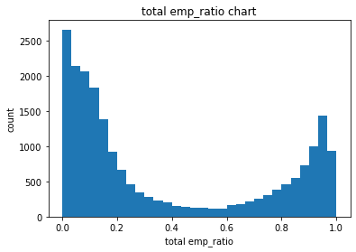

```python
plt.hist(DF.emp_ratio,30)
plt.title('total emp_ratio chart')
plt.xlabel('total emp_ratio')
plt.ylabel('count')
plt.show()
```

```python
DF_U = DF[DF['settlement']=='شهری']
DF_R = DF[DF['settlement']=='روستایی']

X_Urban = DF_U['emp_ratio'].tolist()
X_Rural = DF_R['emp_ratio'].tolist()
sum(DF_U['emp_ratio'].isna())
```

```
0
```

```python
DF_W = DF[DF['gender']=='زن']
DF_M = DF[DF['gender']=='مرد']

X_Women = DF_W['emp_ratio'].tolist()
X_Men = DF_M['emp_ratio'].tolist()
```

```python
X_1014 = DF[DF['age_group']=='10-14 ساله']['emp_ratio'].tolist()
X_1519 = DF[DF['age_group']=='15-19 ساله']['emp_ratio'].tolist()
X_2024 = DF[DF['age_group']=='20-24 ساله']['emp_ratio'].tolist()
X_2529 = DF[DF['age_group']=='25-29 ساله']['emp_ratio'].tolist()
X_3034 = DF[DF['age_group']=='30-34 ساله']['emp_ratio'].tolist()
X_3539 = DF[DF['age_group']=='35-39 ساله']['emp_ratio'].tolist()
X_4044 = DF[DF['age_group']=='40-44 ساله']['emp_ratio'].tolist()
X_4549 = DF[DF['age_group']=='45-49 ساله']['emp_ratio'].tolist()
X_5054 = DF[DF['age_group']=='50-54 ساله']['emp_ratio'].tolist()
X_5559 = DF[DF['age_group']=='55-59 ساله']['emp_ratio'].tolist()
X_6064 = DF[DF['age_group']=='60-64 ساله']['emp_ratio'].tolist()
X_6500 = DF[DF['age_group']=='65 ساله و بيشتر']['emp_ratio'].tolist()
```

```python
def hist_chart(name , x , num_bins):
    plt.hist(x , bins=num_bins,range=(0,1))
    name1 = (name.split('_'))[1]
    name1 += ' emp_ratio'
    plt.title((name1 + ' chart'))
    plt.xlabel(str(name1))
    plt.ylabel('count')
    plt.show()
```

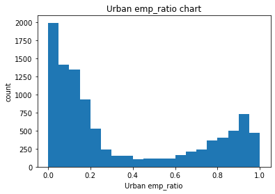

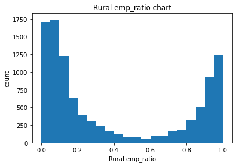

```python
hist_chart('X_Urban', DF_U['emp_ratio'], 20)
hist_chart('X_Rural', X_Rural, 20)
```

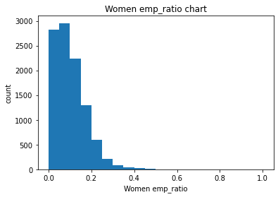

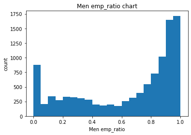

```python
hist_chart('X_Women', X_Women, 20)
hist_chart('X_Men', X_Men, 20)
```

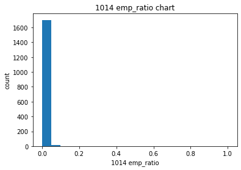

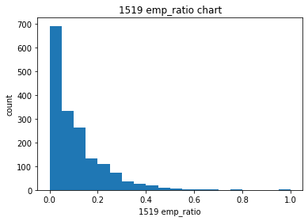

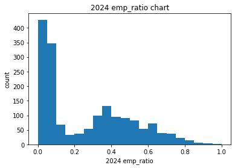

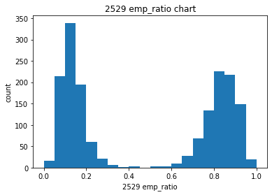

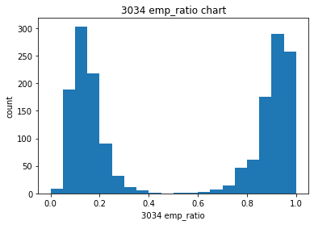

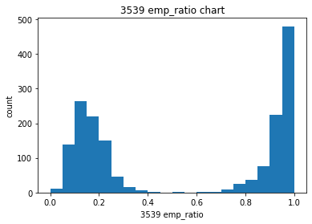

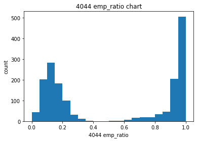

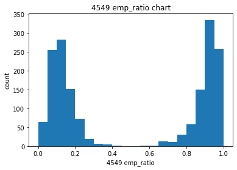

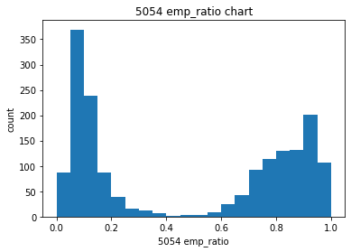

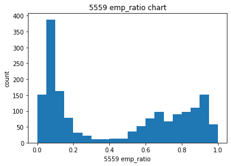

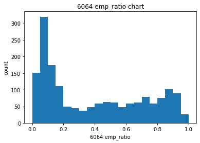

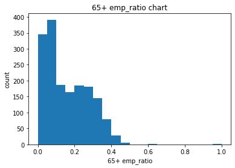

```python
hist_chart('X_1014', X_1014, 20)
hist_chart('X_1519', X_1519, 20)
hist_chart('X_2024', X_2024, 20)
hist_chart('X_2529', X_2529, 20)
hist_chart('X_3034', X_3034, 20)
hist_chart('X_3539', X_3539, 20)
hist_chart('X_4044', X_4044, 20)
hist_chart('X_4549', X_4549, 20)
hist_chart('X_5054', X_5054, 20)
hist_chart('X_5559', X_5559, 20)
hist_chart('X_6064', X_6064, 20)
hist_chart('X_65+', X_6500, 20)
```

# 2.5

نسبت اشتغال در برش سنی 10-14به کمترین حد خود و در برش‌های 35-39 ، 40-44 و 45-49 به بیشترین حد خود می‌رسد جمعیت با سنین 10 تا14 سال بیشتر مشغول تحصیل هستند و برای اشتغال آمادگی کافی ندارند بنابراین نسبت اشتغال در این گروه سنی نزدیک به 0 است جمعیت با سنین 35 تا 50 سال از تحصیل فارغ شده اند و کار مورد نظر خودرا یافته اند و وارد بازار کار شده اند پس در این سنین مقدار میانگین نسبت اشتغال به 1 نزدیکتر است بعد از سن 55 سال با افزایش سن نیروی کار توان آن ها برای کار کردن کمتر می شود و عده ای از آنها بازنشست میشوند بنابراین مقدار میانگین نسبت اشتغال مجددا به 0 نزدیک میشود

```python
DF_faceting=DF[['emp_ratio']]
#تعریف ستون جدید بر اساس حرف اول هر ستون
DF_faceting['sga']=DF['settlement']+' '+DF['gender']+DF['age_group']
```

```python
DF_faceting['sga']=DF_faceting.sga.str.replace("شهری",'urban')
DF_faceting['sga']=DF_faceting.sga.str.replace("روستایی",'rural')
DF_faceting['sga']=DF_faceting.sga.str.replace("مرد",'man')
DF_faceting['sga']=DF_faceting.sga.str.replace("زن",'woman')
DF_faceting['sga']=DF_faceting.sga.str.replace("ساله",'years')
DF_faceting['sga']=DF_faceting.sga.str.replace("و بيشتر",'and more')
```

[output not shown]

```python
DF_faceting
```

|  | emp_ratio | sga |
| --- | --- | --- |
| 0 | 0.005310 | urban man10-14 years |
| 1 | 0.117692 | urban man15-19 years |
| 2 | 0.354014 | urban man20-24 years |
| 3 | 0.776101 | urban man25-29 years |
| 4 | 0.841011 | urban man30-34 years |
| ... | ... | ... |
| 20587 | 0.368217 | rural woman45-49 years |
| 20588 | 0.368984 | rural woman50-54 years |
| 20589 | 0.408046 | rural woman55-59 years |
| 20590 | 0.451220 | rural woman60-64 years |
| 20591 | 0.224615 | rural woman65 years and more |

20592 rows × 2 columns

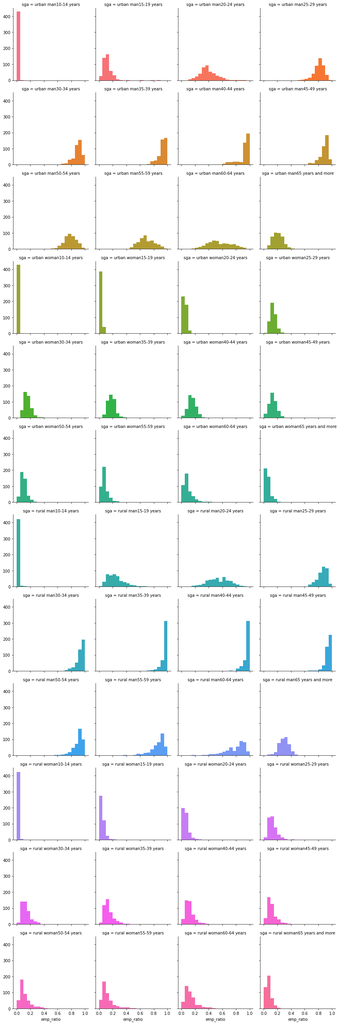

```python
#وارد کردن کتابخانه ی سیبورن
import seaborn as sns
#رنگبندی و تعیین مقادیر نمودار بر اساس ستون sga
g=sns.FacetGrid(DF_faceting,col='sga',hue='sga',col_wrap=4)
g.map(plt.hist,'emp_ratio',range=(0,1),bins=20)
```

# 2.6 & 2.7

Urban emp_ratio & Rural emp_ratio & Women emp_ratio & Men emp_ratio

```python
DF_M
```

|  | county_id | county_name | settlement | gender | age_group | p_active_emp | p_active_unemp | p_inactive_edu | p_inactive_homemaker | p_inactive_incomeNojob | p_inactive_other | p_not_stated | emp_ratio |
| --- | --- | --- | --- | --- | --- | --- | --- | --- | --- | --- | --- | --- | --- |
| 0 | 2301 | تهران | شهری | مرد | 10-14 ساله | 1306 | 54 | 241998 | 124 | 16 | 2282 | 203 | 0.005310 |
| 1 | 2301 | تهران | شهری | مرد | 15-19 ساله | 30154 | 5189 | 210141 | 421 | 137 | 15040 | 318 | 0.117692 |
| 2 | 2301 | تهران | شهری | مرد | 20-24 ساله | 92864 | 32463 | 129952 | 673 | 412 | 37957 | 459 | 0.354014 |
| 3 | 2301 | تهران | شهری | مرد | 25-29 ساله | 260337 | 72162 | 49908 | 1140 | 850 | 22449 | 758 | 0.776101 |
| 4 | 2301 | تهران | شهری | مرد | 30-34 ساله | 375959 | 44063 | 22762 | 1668 | 1373 | 44414 | 856 | 0.841011 |
| ... | ... | ... | ... | ... | ... | ... | ... | ... | ... | ... | ... | ... | ... |
| 20575 | 1708 | لنده | روستایی | مرد | 45-49 ساله | 191 | 2 | 0 | 0 | 6 | 2 | 0 | 0.959799 |
| 20576 | 1708 | لنده | روستایی | مرد | 50-54 ساله | 122 | 0 | 0 | 1 | 5 | 0 | 0 | 0.953125 |
| 20577 | 1708 | لنده | روستایی | مرد | 55-59 ساله | 193 | 0 | 0 | 2 | 12 | 0 | 0 | 0.932367 |
| 20578 | 1708 | لنده | روستایی | مرد | 60-64 ساله | 146 | 0 | 1 | 2 | 8 | 0 | 0 | 0.929936 |
| 20579 | 1708 | لنده | روستایی | مرد | 65 ساله و بيشتر | 113 | 0 | 0 | 5 | 22 | 232 | 0 | 0.303763 |

10296 rows × 13 columns

# 3.1

### نیازمند ترین الگو های اشتغال در میان مردان

```python
DF_M = DF_M[DF_M['age_group'] != '10-14 ساله']
DF_M = DF_M[DF_M['age_group'] != '65 ساله و بيشتر']
```

```python
#تعیین میانگین برای ستون میانگین اشتغال برای هر گروه سنی
L=[]
for i in set(DF_M.age_group):
    D1=DF_M[DF_M.age_group==i][DF_M.settlement=='روستایی'][['county_name' , 'age_group' , 'settlement','emp_ratio']].reset_index().drop(columns=['index'])
    D1['emp_ratio_avg']=D1.emp_ratio.mean()
    D2=DF_M[DF_M.age_group==i][DF_M.settlement=='شهری'][['county_name' , 'age_group' , 'settlement','emp_ratio']].reset_index().drop(columns=['index'])
    D2['emp_ratio_avg']=D1.emp_ratio.mean()
    L.append(D1)
    L.append(D2)
D_N=pd.concat(L)
D_N
```

|  | county_name | age_group | settlement | emp_ratio | emp_ratio_avg |
| --- | --- | --- | --- | --- | --- |
| 0 | تهران | 40-44 ساله | روستایی | 0.966113 | 0.952316 |
| 1 | دماوند | 40-44 ساله | روستایی | 0.880235 | 0.952316 |
| 2 | رئ | 40-44 ساله | روستایی | 0.771017 | 0.952316 |
| 3 | شميرانات | 40-44 ساله | روستایی | 0.866667 | 0.952316 |
| 4 | ورامين | 40-44 ساله | روستایی | 0.840340 | 0.952316 |
| ... | ... | ... | ... | ... | ... |
| 424 | دنا | 35-39 ساله | شهری | 0.944444 | 0.949878 |
| 425 | بهمئي | 35-39 ساله | شهری | 0.891089 | 0.949878 |
| 426 | چرام | 35-39 ساله | شهری | 0.883552 | 0.949878 |
| 427 | باشت | 35-39 ساله | شهری | 0.912281 | 0.949878 |
| 428 | لنده | 35-39 ساله | شهری | 0.893246 | 0.949878 |

8580 rows × 5 columns

```python
#تشکیل ستون اختلاف میانگین با میانگین شهر
D_N['emp_ratio_standard']=D_N.emp_ratio-D_N.emp_ratio_avg
#مرتب سازی مقادیر بر اساس ستون اختلاف با میانگین درصد اشتغال(استاندارد) و یافتن 40 مقدار اول
D_N.sort_values('emp_ratio_standard' , ascending = True).head(40)
```

|  | county_name | age_group | settlement | emp_ratio | emp_ratio_avg | emp_ratio_standard |
| --- | --- | --- | --- | --- | --- | --- |
| 412 | بافق | 60-64 ساله | روستایی | 0.133333 | 0.787508 | -0.654175 |
| 290 | كوهبنان | 60-64 ساله | شهری | 0.140969 | 0.787508 | -0.646539 |
| 412 | بافق | 60-64 ساله | شهری | 0.164706 | 0.787508 | -0.622802 |
| 290 | كوهبنان | 55-59 ساله | شهری | 0.241877 | 0.856092 | -0.614214 |
| 374 | سوادكوه | 60-64 ساله | روستایی | 0.190840 | 0.787508 | -0.596668 |
| 388 | سوادکوه شمالي | 60-64 ساله | شهری | 0.192982 | 0.787508 | -0.594525 |
| 290 | كوهبنان | 60-64 ساله | روستایی | 0.197802 | 0.787508 | -0.589706 |
| 374 | سوادكوه | 60-64 ساله | شهری | 0.199634 | 0.787508 | -0.587874 |
| 240 | البرز | 60-64 ساله | شهری | 0.207509 | 0.787508 | -0.579999 |
| 412 | بافق | 55-59 ساله | روستایی | 0.285714 | 0.856092 | -0.570377 |
| 108 | طبس | 60-64 ساله | شهری | 0.225266 | 0.787508 | -0.562242 |
| 412 | بافق | 55-59 ساله | شهری | 0.295754 | 0.856092 | -0.560338 |
| 257 | شاهين شهروميمه | 60-64 ساله | شهری | 0.227312 | 0.787508 | -0.560196 |
| 375 | قائم شهر | 60-64 ساله | شهری | 0.228121 | 0.787508 | -0.559386 |
| 253 | لنجان | 60-64 ساله | شهری | 0.228340 | 0.787508 | -0.559168 |
| 160 | اميديه | 60-64 ساله | شهری | 0.231280 | 0.787508 | -0.556228 |
| 420 | بهاباد | 60-64 ساله | شهری | 0.238636 | 0.787508 | -0.548872 |
| 281 | زرند | 60-64 ساله | شهری | 0.239645 | 0.787508 | -0.547863 |
| 346 | رودبار | 60-64 ساله | شهری | 0.240781 | 0.787508 | -0.546727 |
| 374 | سوادكوه | 55-59 ساله | شهری | 0.313456 | 0.856092 | -0.542636 |
| 287 | راور | 60-64 ساله | روستایی | 0.245421 | 0.787508 | -0.542087 |
| 181 | سمنان | 60-64 ساله | شهری | 0.250979 | 0.787508 | -0.536529 |
| 258 | مبارکه | 60-64 ساله | شهری | 0.252610 | 0.787508 | -0.534898 |
| 180 | دامغان | 60-64 ساله | شهری | 0.260469 | 0.787508 | -0.527039 |
| 182 | شاهرود | 60-64 ساله | شهری | 0.260782 | 0.787508 | -0.526726 |
| 370 | بهشهر | 60-64 ساله | شهری | 0.266459 | 0.787508 | -0.521049 |
| 423 | گچساران | 60-64 ساله | شهری | 0.267034 | 0.787508 | -0.520474 |
| 254 | نايين | 60-64 ساله | شهری | 0.271501 | 0.787508 | -0.516007 |
| 386 | مياندورود | 60-64 ساله | شهری | 0.274390 | 0.787508 | -0.513118 |
| 10 | قدس | 60-64 ساله | روستایی | 0.274510 | 0.787508 | -0.512998 |
| 374 | سوادكوه | 55-59 ساله | روستایی | 0.343234 | 0.856092 | -0.512857 |
| 28 | جلفا | 60-64 ساله | شهری | 0.277778 | 0.787508 | -0.509730 |
| 156 | شوشتر | 60-64 ساله | شهری | 0.284239 | 0.787508 | -0.503269 |
| 187 | سرخه | 60-64 ساله | شهری | 0.288462 | 0.787508 | -0.499046 |
| 79 | بوشهر | 60-64 ساله | شهری | 0.291524 | 0.787508 | -0.495984 |
| 6 | اسلامشهر | 60-64 ساله | شهری | 0.291942 | 0.787508 | -0.495566 |
| 290 | كوهبنان | 55-59 ساله | روستایی | 0.368056 | 0.856092 | -0.488036 |
| 361 | دورود | 60-64 ساله | شهری | 0.301136 | 0.787508 | -0.486372 |
| 238 | قزوين | 60-64 ساله | شهری | 0.301232 | 0.787508 | -0.486276 |
| 116 | گناباد | 60-64 ساله | شهری | 0.301282 | 0.787508 | -0.486226 |

نیازمند ترین الگو های اشتغال مردان در کشور

```python
L=[]
for i in set(D_N.age_group):
    L.append(D_N[D_N.age_group==i][D_N[D_N.age_group==i].settlement=='شهری'].sort_values('emp_ratio_standard' , ascending = True)[:2])
    L.append(D_N[D_N.age_group==i][D_N[D_N.age_group==i].settlement=='روستایی'].sort_values('emp_ratio_standard' , ascending = True)[:2])
DF_in_need_men=pd.concat(L)
DF_in_need_men
```

|  | county_name | age_group | settlement | emp_ratio | emp_ratio_avg | emp_ratio_standard |
| --- | --- | --- | --- | --- | --- | --- |
| 33 | ورزقان | 15-19 ساله | شهری | 0.023301 | 0.243197 | -0.219896 |
| 364 | پلدختر | 15-19 ساله | شهری | 0.027328 | 0.243197 | -0.215869 |
| 389 | کلاردشت | 15-19 ساله | روستایی | 0.029900 | 0.243197 | -0.213296 |
| 66 | طالقان | 15-19 ساله | روستایی | 0.041096 | 0.243197 | -0.202101 |
| 290 | كوهبنان | 55-59 ساله | شهری | 0.241877 | 0.856092 | -0.614214 |
| 412 | بافق | 55-59 ساله | شهری | 0.295754 | 0.856092 | -0.560338 |
| 412 | بافق | 55-59 ساله | روستایی | 0.285714 | 0.856092 | -0.570377 |
| 374 | سوادكوه | 55-59 ساله | روستایی | 0.343234 | 0.856092 | -0.512857 |
| 290 | كوهبنان | 60-64 ساله | شهری | 0.140969 | 0.787508 | -0.646539 |
| 412 | بافق | 60-64 ساله | شهری | 0.164706 | 0.787508 | -0.622802 |
| 412 | بافق | 60-64 ساله | روستایی | 0.133333 | 0.787508 | -0.654175 |
| 374 | سوادكوه | 60-64 ساله | روستایی | 0.190840 | 0.787508 | -0.596668 |
| 205 | قصرقند | 45-49 ساله | شهری | 0.574661 | 0.939992 | -0.365331 |
| 199 | دلگان | 45-49 ساله | شهری | 0.607143 | 0.939992 | -0.332849 |
| 290 | كوهبنان | 45-49 ساله | روستایی | 0.666667 | 0.939992 | -0.273325 |
| 63 | کرج | 45-49 ساله | روستایی | 0.675637 | 0.939992 | -0.264355 |
| 367 | رومشکان | 20-24 ساله | شهری | 0.107955 | 0.547387 | -0.439432 |
| 422 | كهگيلويه | 20-24 ساله | شهری | 0.137427 | 0.547387 | -0.409960 |
| 207 | آباده | 20-24 ساله | روستایی | 0.156559 | 0.547387 | -0.390828 |
| 200 | مهرستان | 20-24 ساله | روستایی | 0.166026 | 0.547387 | -0.381361 |
| 326 | بشاگرد | 30-34 ساله | شهری | 0.556522 | 0.925290 | -0.368768 |
| 307 | گيلانغرب | 30-34 ساله | شهری | 0.643396 | 0.925290 | -0.281894 |
| 63 | کرج | 30-34 ساله | روستایی | 0.504237 | 0.925290 | -0.421053 |
| 307 | گيلانغرب | 30-34 ساله | روستایی | 0.647059 | 0.925290 | -0.278231 |
| 181 | سمنان | 25-29 ساله | شهری | 0.508219 | 0.854033 | -0.345814 |
| 307 | گيلانغرب | 25-29 ساله | شهری | 0.534937 | 0.854033 | -0.319096 |
| 63 | کرج | 25-29 ساله | روستایی | 0.433431 | 0.854033 | -0.420602 |
| 307 | گيلانغرب | 25-29 ساله | روستایی | 0.541667 | 0.854033 | -0.312366 |
| 206 | فنوج | 40-44 ساله | شهری | 0.549521 | 0.952316 | -0.402795 |
| 205 | قصرقند | 40-44 ساله | شهری | 0.557940 | 0.952316 | -0.394376 |
| 63 | کرج | 40-44 ساله | روستایی | 0.641745 | 0.952316 | -0.310571 |
| 119 | چناران | 40-44 ساله | روستایی | 0.708295 | 0.952316 | -0.244021 |
| 374 | سوادكوه | 50-54 ساله | شهری | 0.484892 | 0.895770 | -0.410878 |
| 290 | كوهبنان | 50-54 ساله | شهری | 0.494083 | 0.895770 | -0.401688 |
| 412 | بافق | 50-54 ساله | روستایی | 0.445783 | 0.895770 | -0.449987 |
| 374 | سوادكوه | 50-54 ساله | روستایی | 0.485342 | 0.895770 | -0.410428 |
| 200 | مهرستان | 35-39 ساله | شهری | 0.647416 | 0.949878 | -0.302461 |
| 205 | قصرقند | 35-39 ساله | شهری | 0.666667 | 0.949878 | -0.283211 |
| 63 | کرج | 35-39 ساله | روستایی | 0.531391 | 0.949878 | -0.418486 |
| 200 | مهرستان | 35-39 ساله | روستایی | 0.606689 | 0.949878 | -0.343189 |

یافتن 2مورد از نیازمند ترین الگو های اشتغال میان مردان برای هر گروه سنی به تفکیک شهر و روستا

```python
DF_in_need_men[['county_name','age_group','settlement']]
```

|  | county_name | age_group | settlement |
| --- | --- | --- | --- |
| 33 | ورزقان | 15-19 ساله | شهری |
| 364 | پلدختر | 15-19 ساله | شهری |
| 389 | کلاردشت | 15-19 ساله | روستایی |
| 66 | طالقان | 15-19 ساله | روستایی |
| 290 | كوهبنان | 55-59 ساله | شهری |
| 412 | بافق | 55-59 ساله | شهری |
| 412 | بافق | 55-59 ساله | روستایی |
| 374 | سوادكوه | 55-59 ساله | روستایی |
| 290 | كوهبنان | 60-64 ساله | شهری |
| 412 | بافق | 60-64 ساله | شهری |
| 412 | بافق | 60-64 ساله | روستایی |
| 374 | سوادكوه | 60-64 ساله | روستایی |
| 205 | قصرقند | 45-49 ساله | شهری |
| 199 | دلگان | 45-49 ساله | شهری |
| 290 | كوهبنان | 45-49 ساله | روستایی |
| 63 | کرج | 45-49 ساله | روستایی |
| 367 | رومشکان | 20-24 ساله | شهری |
| 422 | كهگيلويه | 20-24 ساله | شهری |
| 207 | آباده | 20-24 ساله | روستایی |
| 200 | مهرستان | 20-24 ساله | روستایی |
| 326 | بشاگرد | 30-34 ساله | شهری |
| 307 | گيلانغرب | 30-34 ساله | شهری |
| 63 | کرج | 30-34 ساله | روستایی |
| 307 | گيلانغرب | 30-34 ساله | روستایی |
| 181 | سمنان | 25-29 ساله | شهری |
| 307 | گيلانغرب | 25-29 ساله | شهری |
| 63 | کرج | 25-29 ساله | روستایی |
| 307 | گيلانغرب | 25-29 ساله | روستایی |
| 206 | فنوج | 40-44 ساله | شهری |
| 205 | قصرقند | 40-44 ساله | شهری |
| 63 | کرج | 40-44 ساله | روستایی |
| 119 | چناران | 40-44 ساله | روستایی |
| 374 | سوادكوه | 50-54 ساله | شهری |
| 290 | كوهبنان | 50-54 ساله | شهری |
| 412 | بافق | 50-54 ساله | روستایی |
| 374 | سوادكوه | 50-54 ساله | روستایی |
| 200 | مهرستان | 35-39 ساله | شهری |
| 205 | قصرقند | 35-39 ساله | شهری |
| 63 | کرج | 35-39 ساله | روستایی |
| 200 | مهرستان | 35-39 ساله | روستایی |

حذف ستونهای اضافی با توجه به خواسته ی سوال

# 3.2

### موفق ترین الگو های اشتغال زنان

```python
DF_W = DF_W[DF_W['age_group'] != '10-14 ساله']
DF_W = DF_W[DF_W['age_group'] != '65 ساله و بيشتر']

L=[]
for i in set(DF_W.age_group):
    D1=DF_W[DF_W.age_group==i][DF_W.settlement=='روستایی'][['county_name' , 'age_group' , 'settlement','emp_ratio']].reset_index().drop(columns=['index'])
    D1['emp_ratio_avg']=D1.emp_ratio.mean()
    D2=DF_W[DF_W.age_group==i][DF_W.settlement=='شهری'][['county_name' , 'age_group' , 'settlement','emp_ratio']].reset_index().drop(columns=['index'])
    D2['emp_ratio_avg']=D1.emp_ratio.mean()
    L.append(D1)
    L.append(D2)
D_N=pd.concat(L)
D_N['emp_ratio_standard']=D_N.emp_ratio-D_N.emp_ratio_avg
D_N
```

|  | county_name | age_group | settlement | emp_ratio | emp_ratio_avg | emp_ratio_standard |
| --- | --- | --- | --- | --- | --- | --- |
| 0 | تهران | 40-44 ساله | روستایی | 0.057364 | 0.122068 | -0.064704 |
| 1 | دماوند | 40-44 ساله | روستایی | 0.105116 | 0.122068 | -0.016952 |
| 2 | رئ | 40-44 ساله | روستایی | 0.088100 | 0.122068 | -0.033968 |
| 3 | شميرانات | 40-44 ساله | روستایی | 0.048362 | 0.122068 | -0.073707 |
| 4 | ورامين | 40-44 ساله | روستایی | 0.082327 | 0.122068 | -0.039741 |
| ... | ... | ... | ... | ... | ... | ... |
| 424 | دنا | 35-39 ساله | شهری | 0.214797 | 0.141549 | 0.073248 |
| 425 | بهمئي | 35-39 ساله | شهری | 0.256569 | 0.141549 | 0.115020 |
| 426 | چرام | 35-39 ساله | شهری | 0.176301 | 0.141549 | 0.034752 |
| 427 | باشت | 35-39 ساله | شهری | 0.238095 | 0.141549 | 0.096546 |
| 428 | لنده | 35-39 ساله | شهری | 0.358925 | 0.141549 | 0.217376 |

8580 rows × 6 columns

```python
D_N.sort_values('emp_ratio_standard' , ascending = False).head(40)
```

|  | county_name | age_group | settlement | emp_ratio | emp_ratio_avg | emp_ratio_standard |
| --- | --- | --- | --- | --- | --- | --- |
| 314 | ابوموسي | 15-19 ساله | روستایی | 1.000000 | 0.051199 | 0.948801 |
| 200 | مهرستان | 60-64 ساله | شهری | 0.559524 | 0.134522 | 0.425001 |
| 201 | سيب و سوران | 60-64 ساله | شهری | 0.535484 | 0.134522 | 0.400962 |
| 200 | مهرستان | 55-59 ساله | روستایی | 0.519459 | 0.122624 | 0.396835 |
| 314 | ابوموسي | 35-39 ساله | روستایی | 0.500000 | 0.141549 | 0.358451 |
| 338 | مراوه تپه | 60-64 ساله | شهری | 0.492754 | 0.134522 | 0.358231 |
| 195 | سرباز | 55-59 ساله | روستایی | 0.468750 | 0.122624 | 0.346126 |
| 428 | لنده | 50-54 ساله | شهری | 0.453744 | 0.117172 | 0.336572 |
| 322 | بستك | 60-64 ساله | روستایی | 0.469762 | 0.134522 | 0.335240 |
| 205 | قصرقند | 60-64 ساله | روستایی | 0.467120 | 0.134522 | 0.332598 |
| 112 | درگز | 45-49 ساله | روستایی | 0.434168 | 0.116393 | 0.317775 |
| 428 | لنده | 60-64 ساله | روستایی | 0.451220 | 0.134522 | 0.316697 |
| 200 | مهرستان | 60-64 ساله | روستایی | 0.448889 | 0.134522 | 0.314367 |
| 325 | سيريك | 60-64 ساله | روستایی | 0.448795 | 0.134522 | 0.314273 |
| 195 | سرباز | 60-64 ساله | روستایی | 0.447587 | 0.134522 | 0.313065 |
| 319 | جاسك | 60-64 ساله | روستایی | 0.444201 | 0.134522 | 0.309679 |
| 201 | سيب و سوران | 55-59 ساله | روستایی | 0.432258 | 0.122624 | 0.309634 |
| 144 | راز و جرگلان | 60-64 ساله | روستایی | 0.442647 | 0.134522 | 0.308125 |
| 194 | نيك شهر | 55-59 ساله | روستایی | 0.429520 | 0.122624 | 0.306897 |
| 325 | سيريك | 55-59 ساله | روستایی | 0.425795 | 0.122624 | 0.303171 |
| 88 | عسلويه | 60-64 ساله | روستایی | 0.437500 | 0.134522 | 0.302978 |
| 195 | سرباز | 35-39 ساله | روستایی | 0.443400 | 0.141549 | 0.301851 |
| 322 | بستك | 55-59 ساله | روستایی | 0.414725 | 0.122624 | 0.292101 |
| 193 | سراوان | 55-59 ساله | روستایی | 0.413024 | 0.122624 | 0.290400 |
| 428 | لنده | 60-64 ساله | شهری | 0.424419 | 0.134522 | 0.289896 |
| 27 | هريس | 25-29 ساله | روستایی | 0.419335 | 0.130278 | 0.289057 |
| 324 | پارسيان | 55-59 ساله | روستایی | 0.409877 | 0.122624 | 0.287253 |
| 428 | لنده | 55-59 ساله | روستایی | 0.408046 | 0.122624 | 0.285422 |
| 112 | درگز | 50-54 ساله | روستایی | 0.400000 | 0.117172 | 0.282828 |
| 428 | لنده | 35-39 ساله | روستایی | 0.422222 | 0.141549 | 0.280673 |
| 428 | لنده | 55-59 ساله | شهری | 0.402235 | 0.122624 | 0.279611 |
| 88 | عسلويه | 55-59 ساله | روستایی | 0.400631 | 0.122624 | 0.278007 |
| 88 | عسلويه | 60-64 ساله | شهری | 0.412162 | 0.134522 | 0.277640 |
| 195 | سرباز | 30-34 ساله | روستایی | 0.410733 | 0.134674 | 0.276058 |
| 428 | لنده | 40-44 ساله | روستایی | 0.397476 | 0.122068 | 0.275408 |
| 195 | سرباز | 50-54 ساله | روستایی | 0.391389 | 0.117172 | 0.274217 |
| 195 | سرباز | 25-29 ساله | روستایی | 0.402237 | 0.130278 | 0.271960 |
| 425 | بهمئي | 60-64 ساله | شهری | 0.404110 | 0.134522 | 0.269587 |
| 201 | سيب و سوران | 60-64 ساله | روستایی | 0.402821 | 0.134522 | 0.268299 |
| 311 | ثلاث باباجاني | 15-19 ساله | روستایی | 0.318741 | 0.051199 | 0.267543 |

موفق ترین الگو های اشتغال زنان در کشور

```python
L=[]
for i in set(D_N.age_group):
    L.append(D_N[D_N.age_group==i][D_N[D_N.age_group==i].settlement=='شهری'].sort_values('emp_ratio_standard' , ascending = False)[:2])
    L.append(D_N[D_N.age_group==i][D_N[D_N.age_group==i].settlement=='روستایی'].sort_values('emp_ratio_standard' , ascending = False)[:2])
DF_success_women=pd.concat(L)
DF_success_women
```

|  | county_name | age_group | settlement | emp_ratio | emp_ratio_avg | emp_ratio_standard |
| --- | --- | --- | --- | --- | --- | --- |
| 204 | ميرجاوه | 15-19 ساله | شهری | 0.155882 | 0.051199 | 0.104684 |
| 195 | سرباز | 15-19 ساله | شهری | 0.139688 | 0.051199 | 0.088489 |
| 314 | ابوموسي | 15-19 ساله | روستایی | 1.000000 | 0.051199 | 0.948801 |
| 311 | ثلاث باباجاني | 15-19 ساله | روستایی | 0.318741 | 0.051199 | 0.267543 |
| 428 | لنده | 55-59 ساله | شهری | 0.402235 | 0.122624 | 0.279611 |
| 425 | بهمئي | 55-59 ساله | شهری | 0.363636 | 0.122624 | 0.241013 |
| 200 | مهرستان | 55-59 ساله | روستایی | 0.519459 | 0.122624 | 0.396835 |
| 195 | سرباز | 55-59 ساله | روستایی | 0.468750 | 0.122624 | 0.346126 |
| 200 | مهرستان | 60-64 ساله | شهری | 0.559524 | 0.134522 | 0.425001 |
| 201 | سيب و سوران | 60-64 ساله | شهری | 0.535484 | 0.134522 | 0.400962 |
| 322 | بستك | 60-64 ساله | روستایی | 0.469762 | 0.134522 | 0.335240 |
| 205 | قصرقند | 60-64 ساله | روستایی | 0.467120 | 0.134522 | 0.332598 |
| 428 | لنده | 45-49 ساله | شهری | 0.356354 | 0.116393 | 0.239961 |
| 157 | مسجدسليمان | 45-49 ساله | شهری | 0.295420 | 0.116393 | 0.179027 |
| 112 | درگز | 45-49 ساله | روستایی | 0.434168 | 0.116393 | 0.317775 |
| 428 | لنده | 45-49 ساله | روستایی | 0.368217 | 0.116393 | 0.251824 |
| 195 | سرباز | 20-24 ساله | شهری | 0.224124 | 0.061775 | 0.162349 |
| 12 | پيشوا | 20-24 ساله | شهری | 0.190570 | 0.061775 | 0.128796 |
| 27 | هريس | 20-24 ساله | روستایی | 0.294312 | 0.061775 | 0.232537 |
| 195 | سرباز | 20-24 ساله | روستایی | 0.289596 | 0.061775 | 0.227822 |
| 78 | بدره | 30-34 ساله | شهری | 0.376569 | 0.134674 | 0.241895 |
| 195 | سرباز | 30-34 ساله | شهری | 0.361085 | 0.134674 | 0.226411 |
| 195 | سرباز | 30-34 ساله | روستایی | 0.410733 | 0.134674 | 0.276058 |
| 27 | هريس | 30-34 ساله | روستایی | 0.399866 | 0.134674 | 0.265191 |
| 195 | سرباز | 25-29 ساله | شهری | 0.369191 | 0.130278 | 0.238913 |
| 78 | بدره | 25-29 ساله | شهری | 0.357143 | 0.130278 | 0.226865 |
| 27 | هريس | 25-29 ساله | روستایی | 0.419335 | 0.130278 | 0.289057 |
| 195 | سرباز | 25-29 ساله | روستایی | 0.402237 | 0.130278 | 0.271960 |
| 428 | لنده | 40-44 ساله | شهری | 0.339286 | 0.122068 | 0.217217 |
| 144 | راز و جرگلان | 40-44 ساله | شهری | 0.314286 | 0.122068 | 0.192217 |
| 428 | لنده | 40-44 ساله | روستایی | 0.397476 | 0.122068 | 0.275408 |
| 112 | درگز | 40-44 ساله | روستایی | 0.388753 | 0.122068 | 0.266685 |
| 428 | لنده | 50-54 ساله | شهری | 0.453744 | 0.117172 | 0.336572 |
| 338 | مراوه تپه | 50-54 ساله | شهری | 0.323529 | 0.117172 | 0.206357 |
| 112 | درگز | 50-54 ساله | روستایی | 0.400000 | 0.117172 | 0.282828 |
| 195 | سرباز | 50-54 ساله | روستایی | 0.391389 | 0.117172 | 0.274217 |
| 78 | بدره | 35-39 ساله | شهری | 0.392670 | 0.141549 | 0.251121 |
| 195 | سرباز | 35-39 ساله | شهری | 0.376283 | 0.141549 | 0.234734 |
| 314 | ابوموسي | 35-39 ساله | روستایی | 0.500000 | 0.141549 | 0.358451 |
| 195 | سرباز | 35-39 ساله | روستایی | 0.443400 | 0.141549 | 0.301851 |

یافتن 2 مورد از موفق ترین شهرستان ها برای زنان برای هر گروه سنی به تفکیک شهر و روستا

```python
DF_success_women[['county_name','age_group','settlement']]
```

|  | county_name | age_group | settlement |
| --- | --- | --- | --- |
| 204 | ميرجاوه | 15-19 ساله | شهری |
| 195 | سرباز | 15-19 ساله | شهری |
| 314 | ابوموسي | 15-19 ساله | روستایی |
| 311 | ثلاث باباجاني | 15-19 ساله | روستایی |
| 428 | لنده | 55-59 ساله | شهری |
| 425 | بهمئي | 55-59 ساله | شهری |
| 200 | مهرستان | 55-59 ساله | روستایی |
| 195 | سرباز | 55-59 ساله | روستایی |
| 200 | مهرستان | 60-64 ساله | شهری |
| 201 | سيب و سوران | 60-64 ساله | شهری |
| 322 | بستك | 60-64 ساله | روستایی |
| 205 | قصرقند | 60-64 ساله | روستایی |
| 428 | لنده | 45-49 ساله | شهری |
| 157 | مسجدسليمان | 45-49 ساله | شهری |
| 112 | درگز | 45-49 ساله | روستایی |
| 428 | لنده | 45-49 ساله | روستایی |
| 195 | سرباز | 20-24 ساله | شهری |
| 12 | پيشوا | 20-24 ساله | شهری |
| 27 | هريس | 20-24 ساله | روستایی |
| 195 | سرباز | 20-24 ساله | روستایی |
| 78 | بدره | 30-34 ساله | شهری |
| 195 | سرباز | 30-34 ساله | شهری |
| 195 | سرباز | 30-34 ساله | روستایی |
| 27 | هريس | 30-34 ساله | روستایی |
| 195 | سرباز | 25-29 ساله | شهری |
| 78 | بدره | 25-29 ساله | شهری |
| 27 | هريس | 25-29 ساله | روستایی |
| 195 | سرباز | 25-29 ساله | روستایی |
| 428 | لنده | 40-44 ساله | شهری |
| 144 | راز و جرگلان | 40-44 ساله | شهری |
| 428 | لنده | 40-44 ساله | روستایی |
| 112 | درگز | 40-44 ساله | روستایی |
| 428 | لنده | 50-54 ساله | شهری |
| 338 | مراوه تپه | 50-54 ساله | شهری |
| 112 | درگز | 50-54 ساله | روستایی |
| 195 | سرباز | 50-54 ساله | روستایی |
| 78 | بدره | 35-39 ساله | شهری |
| 195 | سرباز | 35-39 ساله | شهری |
| 314 | ابوموسي | 35-39 ساله | روستایی |
| 195 | سرباز | 35-39 ساله | روستایی |

حذف ستونهای اضافی با توجه به خواسته ی سوال